# Testing Stationarity in $ AR(p) $ Processes - Stock Analysis Pipeline

## 1 - Data Processing

In this stage, collect the time series data and save the time series as a Panda Series $$x = [x_1 \ x_2 \ \dots \ x_n]^T$$ where $ n >> p$.

```python
import pandas as pd
import yfinance as yf

TICKERS = [
    # ----------------------------
    # Mature / range-bound tech
    # ----------------------------
    "CSCO",   # Cisco: mature networking; often less explosive than mega-growth tech
    "IBM",    # IBM: mature enterprise tech; slower-moving legacy tech
    "INTC",   # Intel: cyclical semiconductor, but often more range-bound than NVDA
    "ORCL",   # Oracle: mature enterprise software
    "HPQ",    # HP Inc.: mature hardware / PC exposure

    # ----------------------------
    # Finance / banks / payments
    # ----------------------------
    "JPM",    # JPMorgan: large diversified bank
    "BAC",    # Bank of America: large money-center bank
    "WFC",    # Wells Fargo: large bank, often cyclical
    "C",      # Citigroup: large bank, historically more range-bound
    "GS",     # Goldman Sachs: investment banking / trading exposure
    "MS",     # Morgan Stanley: investment banking / wealth management
    "AXP",    # American Express: finance + payments
    "BLK",    # BlackRock: asset management

    # ----------------------------
    # Telecom / defensive-ish
    # ----------------------------
    "T",      # AT&T: mature telecom
    "VZ",     # Verizon: mature telecom

    # ----------------------------
    # Defensive consumer / healthcare
    # ----------------------------
    "KO",     # Coca-Cola: defensive consumer staple
    "PG",     # Procter & Gamble: defensive consumer staple
    "WMT",    # Walmart: defensive retail
    "JNJ",    # Johnson & Johnson: defensive healthcare
]
START_DATE = "2020-01-01"
END_DATE = "2026-04-15"
data = yf.download(TICKERS, start=START_DATE, end=END_DATE)
```

```
[*********************100%***********************]  19 of 19 completed
```

```python
TICKER = "INTC"
x_df = pd.Series(data['Close'][TICKER])
print(x_df.shape)
print(x_df.head(5))
```

```
(1578,)
Date
2020-01-02    53.666458
2020-01-03    53.013710
2020-01-06    52.863762
2020-01-07    51.981678
2020-01-08    52.016949
Name: INTC, dtype: float64
```

## 2 - Lag Selection

### PACF-Informed AIC/BIC Selection Over Train Ratios

The train ratio and lag order are coupled. If the training window changes, the PACF changes, the residual variance changes, and the AIC/BIC-optimal lag order may change.

Therefore, for each candidate training ratio (r), we:

1. Split the series into train/test using (r).
2. Compute PACF on the training set.
3. Use significant PACF lags to define a candidate maximum lag.
4. Fit AR$(p)$ models for $p = 1,\dots,p_{\max}^{PACF}$.
5. Compute AIC and BIC on the training set.
6. For each train ratio, choose the BIC-best lag.
7. Among those BIC-selected models, choose the train-ratio/lag-order pair with the best one-step test $R^2$.

This makes the test set act as a validation set, so the resulting $R^2$ should be interpreted as validation performance rather than an untouched final test estimate.

```python
from statsmodels.tsa.stattools import pacf
from IPython.display import display, HTML

import matplotlib.pyplot as plt
import numpy as np
import pandas as pd
import math

# --------------------------------------------------
# Helper: AR design matrix
# --------------------------------------------------

def build_ar_design(series, p):
    """
    Build constant-mean AR(p) design matrix.

    Model:
        x_t = a_0 + a_1 x_{t-1} + ... + a_p x_{t-p} + epsilon_t

    Returns:
        X_p: intercept + lag matrix
        y_p: aligned target vector
    """
    series = np.asarray(series).ravel()

    X_lags = np.column_stack([
        series[p - 1 - i : len(series) - 1 - i]
        for i in range(p)
    ])

    X_p = np.column_stack([np.ones(len(X_lags)), X_lags])

    y_p = series[p:]

    return X_p, y_p


# --------------------------------------------------
# Joint train-ratio / lag-order selection
# --------------------------------------------------

MAX_LAG = 30
PACF_BUFFER = 5

TRAIN_RATIO_CANDIDATES = [0.50, 0.60, 0.70, 0.80]

x = x_df.dropna().to_numpy().ravel()

selection_rows = []
pacf_records = {}

for train_ratio in TRAIN_RATIO_CANDIDATES:

    split_idx = math.floor(train_ratio * len(x))
    x_train = x[:split_idx]
    x_test = x[split_idx:]

    if len(x_train) <= MAX_LAG + 5 or len(x_test) <= MAX_LAG + 5:
        continue

    # --------------------------------------------------
    # PACF on this training split
    # --------------------------------------------------

    pacf_values = pacf(x_train, nlags=MAX_LAG, method="ywm")

    n_train = len(x_train)
    threshold = 1.96 / np.sqrt(n_train)

    lags = np.arange(len(pacf_values))

    significant_lags = lags[
        (np.abs(pacf_values) > threshold) & (lags > 0)
    ]

    if len(significant_lags) > 0:
        PACF_SUGGESTED_LAG = int(significant_lags.max())
    else:
        PACF_SUGGESTED_LAG = 1

    PACF_INFORMED_MAX_LAG = min(
        MAX_LAG,
        max(5, PACF_SUGGESTED_LAG + PACF_BUFFER)
    )

    pacf_records[train_ratio] = {
        "split_idx": split_idx,
        "x_train": x_train,
        "x_test": x_test,
        "pacf_values": pacf_values,
        "threshold": threshold,
        "lags": lags,
        "significant_lags": significant_lags,
        "PACF_SUGGESTED_LAG": PACF_SUGGESTED_LAG,
        "PACF_INFORMED_MAX_LAG": PACF_INFORMED_MAX_LAG,
    }

    # --------------------------------------------------
    # AIC/BIC over candidate lag orders for this split
    # --------------------------------------------------

    for p in range(1, PACF_INFORMED_MAX_LAG + 1):

        if len(x_train) <= p + 1 or len(x_test) <= p + 1:
            continue

        X_train_p, y_train_p = build_ar_design(x_train, p)
        X_test_p, y_test_p = build_ar_design(x_test, p)

        # Least-squares estimate
        a_hat_p = np.linalg.inv(X_train_p.T @ X_train_p) @ X_train_p.T @ y_train_p

        # Training fit
        y_train_hat_p = X_train_p @ a_hat_p
        train_resid_p = y_train_p - y_train_hat_p

        # One-step observed-lag test fit
        y_test_hat_p = X_test_p @ a_hat_p
        test_resid_p = y_test_p - y_test_hat_p

        RSS_train_p = np.dot(train_resid_p, train_resid_p)
        RSS_test_p = np.dot(test_resid_p, test_resid_p)

        n_p = len(y_train_p)
        k_p = X_train_p.shape[1]

        sigma2_hat_p = RSS_train_p / n_p

        AIC_p = n_p * np.log(sigma2_hat_p) + 2 * k_p
        BIC_p = n_p * np.log(sigma2_hat_p) + k_p * np.log(n_p)

        TSS_test_p = np.dot(
            y_test_p - np.mean(y_test_p),
            y_test_p - np.mean(y_test_p)
        )

        Test_R2_OneStep_p = 1 - RSS_test_p / TSS_test_p

        selection_rows.append({
            "Train_Ratio": train_ratio,
            "Train_Size": len(x_train),
            "Test_Size": len(x_test),
            "PACF_Suggested_Lag": PACF_SUGGESTED_LAG,
            "PACF_Informed_Max_Lag": PACF_INFORMED_MAX_LAG,
            "Lag_Order": p,
            "RSS_Train": RSS_train_p,
            "RSS_Test": RSS_test_p,
            "Sigma2_hat": sigma2_hat_p,
            "AIC": AIC_p,
            "BIC": BIC_p,
            "Test_R2_OneStep": Test_R2_OneStep_p,
        })


selection_df = pd.DataFrame(selection_rows)

display(
    HTML(
        selection_df.round(6).to_html(index=False)
        .replace(
            '<table border="1" class="dataframe">',
            '<table border="1" class="dataframe" style="margin-left:auto; margin-right:auto; text-align:center;">'
        )
    )
)

# --------------------------------------------------
# Best AIC and BIC model inside each train ratio
# --------------------------------------------------

aic_best_by_ratio = (
    selection_df
    .sort_values(["Train_Ratio", "AIC"])
    .groupby("Train_Ratio")
    .head(1)
    .reset_index(drop=True)
)

bic_best_by_ratio = (
    selection_df
    .sort_values(["Train_Ratio", "BIC"])
    .groupby("Train_Ratio")
    .head(1)
    .reset_index(drop=True)
)

print("Best AIC model by train ratio:")
display(
    HTML(
        aic_best_by_ratio.round(6).to_html(index=False)
        .replace(
            '<table border="1" class="dataframe">',
            '<table border="1" class="dataframe" style="margin-left:auto; margin-right:auto; text-align:center;">'
        )
    )
)

print("Best BIC model by train ratio:")
display(
    HTML(
        bic_best_by_ratio.round(6).to_html(index=False)
        .replace(
            '<table border="1" class="dataframe">',
            '<table border="1" class="dataframe" style="margin-left:auto; margin-right:auto; text-align:center;">'
        )
    )
)

# --------------------------------------------------
# Final validation-selected choice
# --------------------------------------------------

best_row = bic_best_by_ratio.loc[
    bic_best_by_ratio["Test_R2_OneStep"].idxmax()
]

TRAIN_RATIO = float(best_row["Train_Ratio"])
LAG_ORDER = int(best_row["Lag_Order"])

print()
print("Final validation-selected settings:")
print(f"TRAIN_RATIO = {TRAIN_RATIO}")
print(f"LAG_ORDER = {LAG_ORDER}")
print(f"Validation one-step R² = {best_row['Test_R2_OneStep']:.6f}")
print(f"BIC = {best_row['BIC']:.6f}")
```

| Train_Ratio | Train_Size | Test_Size | PACF_Suggested_Lag | PACF_Informed_Max_Lag | Lag_Order | RSS_Train | RSS_Test | Sigma2_hat | AIC | BIC | Test_R2_OneStep |
| --- | --- | --- | --- | --- | --- | --- | --- | --- | --- | --- | --- |
| 0.5 | 789 | 789 | 10 | 15 | 1 | 1135.034954 | 1068.438080 | 1.440400 | 291.557461 | 300.896457 | 0.984276 |
| 0.5 | 789 | 789 | 10 | 15 | 2 | 1079.441913 | 1138.225486 | 1.371591 | 254.669327 | 268.674012 | 0.983237 |
| 0.5 | 789 | 789 | 10 | 15 | 3 | 1074.826543 | 1136.137894 | 1.367464 | 253.984815 | 272.652642 | 0.983257 |
| 0.5 | 789 | 789 | 10 | 15 | 4 | 1071.489892 | 1143.649260 | 1.364955 | 254.230506 | 277.558924 | 0.983133 |
| 0.5 | 789 | 789 | 10 | 15 | 5 | 1069.189649 | 1148.601011 | 1.363762 | 255.233870 | 283.220324 | 0.983046 |
| 0.5 | 789 | 789 | 10 | 15 | 6 | 1068.017394 | 1140.272100 | 1.364007 | 257.064035 | 289.705964 | 0.983156 |
| 0.5 | 789 | 789 | 10 | 15 | 7 | 1062.961620 | 1147.676952 | 1.359286 | 256.042354 | 293.337191 | 0.983034 |
| 0.5 | 789 | 789 | 10 | 15 | 8 | 1060.384419 | 1149.566761 | 1.357727 | 256.838884 | 298.784060 | 0.982996 |
| 0.5 | 789 | 789 | 10 | 15 | 9 | 1047.884213 | 1145.785373 | 1.343441 | 250.282875 | 296.875814 | 0.983043 |
| 0.5 | 789 | 789 | 10 | 15 | 10 | 1032.803684 | 1151.513453 | 1.325807 | 241.694640 | 292.932761 | 0.982948 |
| 0.5 | 789 | 789 | 10 | 15 | 11 | 1031.912152 | 1150.934153 | 1.326365 | 243.740105 | 299.620823 | 0.982945 |
| 0.5 | 789 | 789 | 10 | 15 | 12 | 1030.146939 | 1150.372208 | 1.325800 | 245.126727 | 305.647452 | 0.982942 |
| 0.5 | 789 | 789 | 10 | 15 | 13 | 1029.253282 | 1151.220728 | 1.326357 | 247.170592 | 312.328727 | 0.982921 |
| 0.5 | 789 | 789 | 10 | 15 | 14 | 1023.067939 | 1144.654248 | 1.320088 | 245.216063 | 315.009008 | 0.983011 |
| 0.5 | 789 | 789 | 10 | 15 | 15 | 1021.208094 | 1150.198184 | 1.319390 | 246.529377 | 320.954527 | 0.982921 |
| 0.6 | 946 | 632 | 10 | 15 | 1 | 1223.952076 | 982.463817 | 1.295187 | 248.429335 | 258.131705 | 0.985185 |
| 0.6 | 946 | 632 | 10 | 15 | 2 | 1177.418763 | 1030.899066 | 1.247266 | 214.580261 | 229.130639 | 0.984451 |
| 0.6 | 946 | 632 | 10 | 15 | 3 | 1170.730034 | 1033.473591 | 1.241495 | 211.986470 | 231.382735 | 0.984409 |
| 0.6 | 946 | 632 | 10 | 15 | 4 | 1168.962151 | 1036.344065 | 1.240936 | 213.346063 | 237.586089 | 0.984362 |
| 0.6 | 946 | 632 | 10 | 15 | 5 | 1166.326870 | 1042.751094 | 1.239455 | 214.005903 | 243.087561 | 0.984260 |
| 0.6 | 946 | 632 | 10 | 15 | 6 | 1164.912234 | 1034.930163 | 1.239268 | 215.649883 | 249.571042 | 0.984373 |
| 0.6 | 946 | 632 | 10 | 15 | 7 | 1160.133152 | 1038.876550 | 1.235499 | 214.574635 | 253.333159 | 0.984310 |
| 0.6 | 946 | 632 | 10 | 15 | 8 | 1157.990227 | 1040.775398 | 1.234531 | 215.628411 | 259.222160 | 0.984277 |
| 0.6 | 946 | 632 | 10 | 15 | 9 | 1143.341886 | 1041.121734 | 1.220215 | 206.488720 | 254.915553 | 0.984269 |
| 0.6 | 946 | 632 | 10 | 15 | 10 | 1129.312369 | 1045.104964 | 1.206530 | 197.732808 | 250.990579 | 0.984206 |
| 0.6 | 946 | 632 | 10 | 15 | 11 | 1128.786747 | 1044.791532 | 1.207259 | 200.109242 | 258.195800 | 0.984208 |
| 0.6 | 946 | 632 | 10 | 15 | 12 | 1127.906675 | 1042.680320 | 1.207609 | 202.191867 | 265.105061 | 0.984238 |
| 0.6 | 946 | 632 | 10 | 15 | 13 | 1127.037929 | 1041.851896 | 1.207972 | 204.283789 | 272.021462 | 0.984250 |
| 0.6 | 946 | 632 | 10 | 15 | 14 | 1118.937832 | 1036.315203 | 1.200577 | 200.371776 | 272.931769 | 0.984332 |
| 0.6 | 946 | 632 | 10 | 15 | 15 | 1118.088321 | 1035.411812 | 1.200954 | 202.481343 | 279.861491 | 0.984346 |
| 0.7 | 1104 | 474 | 10 | 15 | 1 | 1397.624059 | 808.893499 | 1.267112 | 265.124169 | 275.135748 | 0.982618 |
| 0.7 | 1104 | 474 | 10 | 15 | 2 | 1356.555787 | 840.657608 | 1.230994 | 235.020138 | 250.034784 | 0.981936 |
| 0.7 | 1104 | 474 | 10 | 15 | 3 | 1347.402016 | 847.941755 | 1.223798 | 230.357352 | 250.373249 | 0.981778 |
| 0.7 | 1104 | 474 | 10 | 15 | 4 | 1345.056229 | 851.674847 | 1.222778 | 231.238202 | 256.253529 | 0.981696 |
| 0.7 | 1104 | 474 | 10 | 15 | 5 | 1340.535935 | 861.613852 | 1.219778 | 230.337022 | 260.349958 | 0.981482 |
| 0.7 | 1104 | 474 | 10 | 15 | 6 | 1340.029955 | 856.979218 | 1.220428 | 232.723384 | 267.732103 | 0.981581 |
| 0.7 | 1104 | 474 | 10 | 15 | 7 | 1335.097246 | 860.722001 | 1.217044 | 231.478172 | 271.480847 | 0.981500 |
| 0.7 | 1104 | 474 | 10 | 15 | 8 | 1331.074200 | 867.082055 | 1.214484 | 230.973730 | 275.968532 | 0.981362 |
| 0.7 | 1104 | 474 | 10 | 15 | 9 | 1320.076957 | 862.268106 | 1.205550 | 224.694561 | 274.679657 | 0.981465 |
| 0.7 | 1104 | 474 | 10 | 15 | 10 | 1306.542787 | 864.024506 | 1.194280 | 216.232973 | 271.206529 | 0.981427 |
| 0.7 | 1104 | 474 | 10 | 15 | 11 | 1305.977840 | 863.973038 | 1.194856 | 218.582258 | 278.542436 | 0.981427 |
| 0.7 | 1104 | 474 | 10 | 15 | 12 | 1304.406413 | 862.427272 | 1.194511 | 220.089026 | 285.033986 | 0.981459 |
| 0.7 | 1104 | 474 | 10 | 15 | 13 | 1303.543218 | 862.278272 | 1.194815 | 222.188620 | 292.116520 | 0.981461 |
| 0.7 | 1104 | 474 | 10 | 15 | 14 | 1294.400780 | 856.782459 | 1.187524 | 217.338490 | 292.247484 | 0.981578 |
| 0.7 | 1104 | 474 | 10 | 15 | 15 | 1293.192813 | 859.465911 | 1.187505 | 219.149404 | 299.037646 | 0.981519 |
| 0.8 | 1262 | 316 | 10 | 15 | 1 | 1530.072502 | 675.951541 | 1.213380 | 247.890091 | 258.169412 | 0.982536 |
| 0.8 | 1262 | 316 | 10 | 15 | 2 | 1497.754437 | 693.792602 | 1.188694 | 223.797581 | 239.214182 | 0.982009 |
| 0.8 | 1262 | 316 | 10 | 15 | 3 | 1488.664939 | 701.346303 | 1.182419 | 218.960494 | 239.512786 | 0.981746 |
| 0.8 | 1262 | 316 | 10 | 15 | 4 | 1485.975215 | 705.400038 | 1.181220 | 219.517521 | 245.203913 | 0.981573 |
| 0.8 | 1262 | 316 | 10 | 15 | 5 | 1481.558304 | 715.437086 | 1.178646 | 218.608706 | 249.427605 | 0.981246 |
| 0.8 | 1262 | 316 | 10 | 15 | 6 | 1481.122904 | 711.554542 | 1.179238 | 221.074774 | 257.024586 | 0.981283 |
| 0.8 | 1262 | 316 | 10 | 15 | 7 | 1477.532276 | 710.281065 | 1.177317 | 220.863367 | 261.942494 | 0.981269 |
| 0.8 | 1262 | 316 | 10 | 15 | 8 | 1472.679697 | 718.498982 | 1.174386 | 219.574509 | 265.781352 | 0.981008 |
| 0.8 | 1262 | 316 | 10 | 15 | 9 | 1462.027988 | 714.537393 | 1.166822 | 213.317637 | 264.650597 | 0.981068 |
| 0.8 | 1262 | 316 | 10 | 15 | 10 | 1449.094930 | 715.239984 | 1.157424 | 205.038522 | 261.495995 | 0.981001 |
| 0.8 | 1262 | 316 | 10 | 15 | 11 | 1448.498632 | 714.889230 | 1.157873 | 207.377037 | 268.957419 | 0.980954 |
| 0.8 | 1262 | 316 | 10 | 15 | 12 | 1447.449027 | 712.478192 | 1.157959 | 209.323955 | 276.025639 | 0.980956 |
| 0.8 | 1262 | 316 | 10 | 15 | 13 | 1446.626816 | 712.387741 | 1.158228 | 211.467210 | 283.288590 | 0.980889 |
| 0.8 | 1262 | 316 | 10 | 15 | 14 | 1437.038829 | 707.608594 | 1.151473 | 206.020862 | 282.960325 | 0.980947 |
| 0.8 | 1262 | 316 | 10 | 15 | 15 | 1435.660832 | 710.528213 | 1.151292 | 207.683080 | 289.739015 | 0.980800 |

```
Best AIC model by train ratio:
```

| Train_Ratio | Train_Size | Test_Size | PACF_Suggested_Lag | PACF_Informed_Max_Lag | Lag_Order | RSS_Train | RSS_Test | Sigma2_hat | AIC | BIC | Test_R2_OneStep |
| --- | --- | --- | --- | --- | --- | --- | --- | --- | --- | --- | --- |
| 0.5 | 789 | 789 | 10 | 15 | 10 | 1032.803684 | 1151.513453 | 1.325807 | 241.694640 | 292.932761 | 0.982948 |
| 0.6 | 946 | 632 | 10 | 15 | 10 | 1129.312369 | 1045.104964 | 1.206530 | 197.732808 | 250.990579 | 0.984206 |
| 0.7 | 1104 | 474 | 10 | 15 | 10 | 1306.542787 | 864.024506 | 1.194280 | 216.232973 | 271.206529 | 0.981427 |
| 0.8 | 1262 | 316 | 10 | 15 | 10 | 1449.094930 | 715.239984 | 1.157424 | 205.038522 | 261.495995 | 0.981001 |

```
Best BIC model by train ratio:
```

| Train_Ratio | Train_Size | Test_Size | PACF_Suggested_Lag | PACF_Informed_Max_Lag | Lag_Order | RSS_Train | RSS_Test | Sigma2_hat | AIC | BIC | Test_R2_OneStep |
| --- | --- | --- | --- | --- | --- | --- | --- | --- | --- | --- | --- |
| 0.5 | 789 | 789 | 10 | 15 | 2 | 1079.441913 | 1138.225486 | 1.371591 | 254.669327 | 268.674012 | 0.983237 |
| 0.6 | 946 | 632 | 10 | 15 | 2 | 1177.418763 | 1030.899066 | 1.247266 | 214.580261 | 229.130639 | 0.984451 |
| 0.7 | 1104 | 474 | 10 | 15 | 2 | 1356.555787 | 840.657608 | 1.230994 | 235.020138 | 250.034784 | 0.981936 |
| 0.8 | 1262 | 316 | 10 | 15 | 2 | 1497.754437 | 693.792602 | 1.188694 | 223.797581 | 239.214182 | 0.982009 |

```
Final validation-selected settings:
TRAIN_RATIO = 0.6
LAG_ORDER = 2
Validation one-step R² = 0.984451
BIC = 229.130639
```

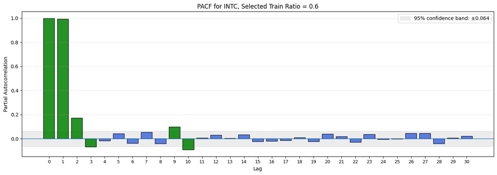

```
Selected train ratio: 0.6
PACF threshold: ±0.0637
Significant PACF lags: [ 1  2  3  9 10]
PACF-suggested lag order: 10
PACF-informed max lag: 15
```

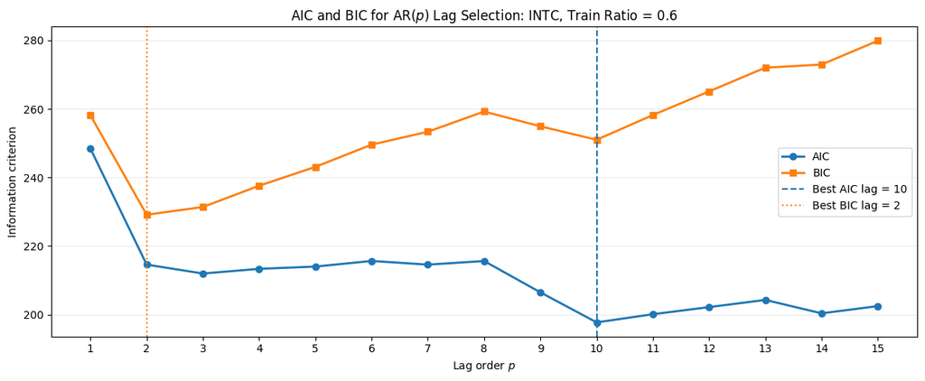

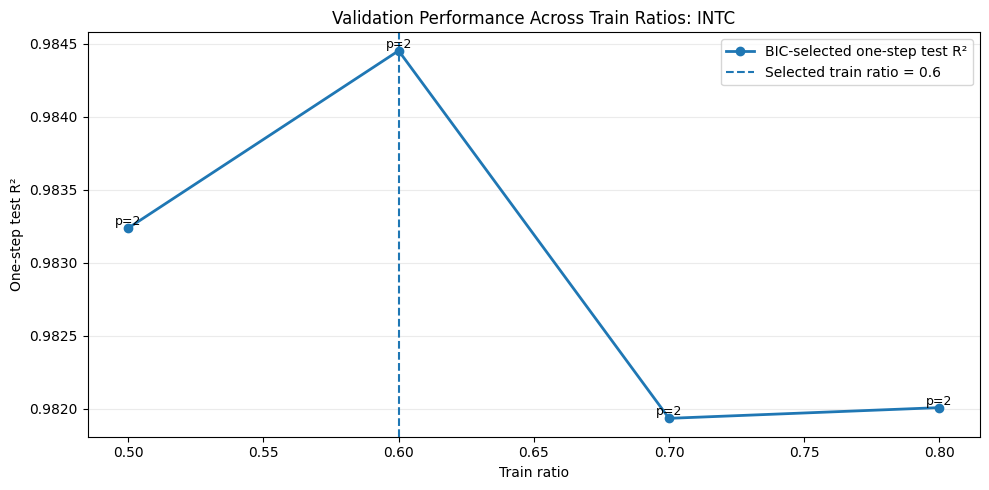

```python
# ==================================================
# Three diagnostic graphs for the selected model
# ==================================================

# --------------------------------------------------
# 1) PACF plot for the selected train ratio
# --------------------------------------------------

record = pacf_records[TRAIN_RATIO]

pacf_values = record["pacf_values"]
threshold = record["threshold"]
lags = record["lags"]

great_lags = np.abs(pacf_values) > threshold
colors = np.where(great_lags, "green", "royalblue")

plt.figure(figsize=(14, 5))

plt.axhspan(
    -threshold,
    threshold,
    alpha=0.15,
    color="gray",
    label=f"95% confidence band: ±{threshold:.3f}"
)

plt.bar(
    lags,
    pacf_values,
    color=colors,
    alpha=0.85,
    edgecolor="black",
    width=0.8
)

plt.axhline(0, linewidth=1)
plt.xticks(lags, fontsize=9)

plt.title(
    f"PACF for {TICKER}, Selected Train Ratio = {TRAIN_RATIO}"
)
plt.xlabel("Lag")
plt.ylabel("Partial Autocorrelation")
plt.grid(axis="y", alpha=0.25)
plt.legend()
plt.tight_layout()
plt.show()

print(f"Selected train ratio: {TRAIN_RATIO}")
print(f"PACF threshold: ±{threshold:.4f}")
print("Significant PACF lags:", record["significant_lags"])
print(f"PACF-suggested lag order: {record['PACF_SUGGESTED_LAG']}")
print(f"PACF-informed max lag: {record['PACF_INFORMED_MAX_LAG']}")


# --------------------------------------------------
# 2) AIC/BIC plot for the selected train ratio
# --------------------------------------------------

selected_ratio_df = selection_df[
    selection_df["Train_Ratio"] == TRAIN_RATIO
].copy()

best_by_aic_selected = int(
    selected_ratio_df.loc[selected_ratio_df["AIC"].idxmin(), "Lag_Order"]
)

best_by_bic_selected = int(
    selected_ratio_df.loc[selected_ratio_df["BIC"].idxmin(), "Lag_Order"]
)

plt.figure(figsize=(12, 5))

plt.plot(
    selected_ratio_df["Lag_Order"],
    selected_ratio_df["AIC"],
    marker="o",
    linewidth=2,
    color="tab:blue",
    label="AIC"
)

plt.plot(
    selected_ratio_df["Lag_Order"],
    selected_ratio_df["BIC"],
    marker="s",
    linewidth=2,
    color="tab:orange",
    label="BIC"
)

plt.axvline(
    best_by_aic_selected,
    linestyle="--",
    linewidth=1.5,
    color="tab:blue",
    label=f"Best AIC lag = {best_by_aic_selected}"
)

plt.axvline(
    best_by_bic_selected,
    linestyle=":",
    linewidth=1.5,
    color="tab:orange",
    label=f"Best BIC lag = {best_by_bic_selected}"
)

plt.xticks(selected_ratio_df["Lag_Order"])
plt.xlabel("Lag order $p$")
plt.ylabel("Information criterion")

plt.title(
    f"AIC and BIC for AR($p$) Lag Selection: {TICKER}, "
    f"Train Ratio = {TRAIN_RATIO}"
)

plt.grid(axis="y", alpha=0.25)
plt.legend()
plt.tight_layout()
plt.show()


# --------------------------------------------------
# 3) Validation performance across train ratios
# --------------------------------------------------

# Each point represents the BIC-best model for that train ratio.
summary_df = bic_best_by_ratio.sort_values("Train_Ratio").copy()

plt.figure(figsize=(10, 5))

plt.plot(
    summary_df["Train_Ratio"],
    summary_df["Test_R2_OneStep"],
    marker="o",
    linewidth=2,
    label="BIC-selected one-step test R²"
)

plt.axvline(
    TRAIN_RATIO,
    linestyle="--",
    linewidth=1.5,
    label=f"Selected train ratio = {TRAIN_RATIO}"
)

# Annotate each point with its BIC-selected lag order
for _, row in summary_df.iterrows():
    plt.text(
        row["Train_Ratio"],
        row["Test_R2_OneStep"],
        f"p={int(row['Lag_Order'])}",
        ha="center",
        va="bottom",
        fontsize=9
    )

plt.xlabel("Train ratio")
plt.ylabel("One-step test R²")
plt.title(
    f"Validation Performance Across Train Ratios: {TICKER}"
)
plt.grid(axis="y", alpha=0.25)
plt.legend()
plt.tight_layout()
plt.show()
```

## 2 - Inference

Let $\hat{x}$ be assumed to follow the $AR(p)$ model with mean intercept. Recall that at each time $t > p$, $$ x_t = a_0 + a_1 x_{t-1} + \dots + a_p x_{t-p} + c + \epsilon_t \\ = a_0 + x_{t-1:t-p}a + \epsilon_t$$ where $$a_0: \text{mean-intercept constant}, \\ a = [a_0 \ a_1 \ a_2 \ \dots \ a_p]^T: \text{model coefficients}, \\ x_{t-1:t-p} = [x_{t-1} \ x_{t-2} \ \dots \ x_{t-p}]^T: \text{$p$ timepoints to the past from timepoint $t$}, \\ \epsilon_t : \text{ zero-mean, constant-variance, uncorrelated noise observations}.$$

Consider all model-able timepoints. Thus, ignore the first $p$ timepoints). Thus,

$$x = [x_{p+1} \ x_{p+2} \ \dots \ x_{n}]^T.$$

Then, write the time series based on the autoregressive model as follows: $$x = \begin{bmatrix} x_p \\ x_{p+1} \\ \vdots \\ x_n \end{bmatrix} = \begin{bmatrix} & 1 \ x_p \ x_{p-1} \ \dots \ x_1 \\ &1 \ x_{p+1} \ x_{p} \ \dots \ x_{2} \\ &\vdots \ \vdots \ \dots \ \vdots \\ & 1 \ x_{n-1} \ x_{n-2} \ \dots \ x_{n-1-p} \end{bmatrix} \begin{bmatrix} a_0 \\ a_1 \\ a_2 \\ \vdots \\ a_p\end{bmatrix} + \begin{bmatrix} \epsilon_p \\ \epsilon_{p+1} \\ \vdots \\ \epsilon_{n} \end{bmatrix} \\ = \begin{bmatrix} 1 \ x_{p:1}^T \\ 1 \ x_{p+1:2}^T \\ \vdots \\ 1 \ x_{n-1:n-1-p}^T \end{bmatrix} a + \epsilon \\ = X a + \epsilon.$$

Estimate the time series by estimating the optimal coefficients as minimizers of the least-squares error objective:

$$ \hat{a} := \arg\min_a \|x - Xa\|_2^2, \qquad \hat{x} := X\hat{a}. $$

The least-squares objective is $$ \|x - Xa\|_2^2 = (x - Xa)^T(x - Xa). $$

The optimal coefficients $\hat{a}$ occur when the first-order derivative is zero: $$ 0 = \frac{\partial}{\partial a} (x - Xa)^T(x - Xa)\bigg|_{a=\hat{a}} = -2X^T(x - X\hat{a}) $$

Equivalently: $$ X^T X \hat{a} = X^T x $$

If $X^T X$ is invertible, then $$ \boxed{\hat{a} = (X^T X)^{-1}X^T x} $$

```python
LAG_ORDER = LAG_ORDER
TRAIN_RATIO = TRAIN_RATIO
```

```python
import numpy as np
import math
x = x_df.to_numpy()

x_train = x[:math.floor(TRAIN_RATIO*len(x))]
x_test = x[math.floor(TRAIN_RATIO*len(x)):]

X_train = np.column_stack(
    [np.ones(len(x_train)-LAG_ORDER)] +
    [x_train[LAG_ORDER-1-i : len(x_train)-1-i]
    for i in range(LAG_ORDER)]
)

X_test = np.column_stack(
    [np.ones(len(x_test)-LAG_ORDER)] +
    [x_test[LAG_ORDER-1-i : len(x_test)-1-i]
    for i in range(LAG_ORDER)
])

x_train_slice = x_train[LAG_ORDER:]
x_test_slice = x_test[LAG_ORDER:]

print(x_train_slice.shape)
print(X_train.shape)
print(x_test_slice.shape)
print(X_test.shape)
```

```
(944,)
(944, 3)
(630,)
(630, 3)
```

```python
a_hat = np.matmul(np.matmul(np.linalg.inv(np.matmul(X_train.T, X_train)), X_train.T), x_train_slice)
print(a_hat)
```

```
[0.21777776 0.80008915 0.19426646]
```

```python
x_train_hat = np.matmul(X_train, np.array(a_hat))

# Recursive forecasting on the test set:
# after the train/test split, every new forecast uses previously forecasted values
# rather than the original future observations.
a_hat_flat = np.asarray(a_hat).ravel()
history = list(np.asarray(x_train[-LAG_ORDER:]).ravel())
x_test_hat = []

for _ in range(len(x_test)):
    lag_values = np.asarray(history[::-1], dtype=float).ravel()
    lag_vector = np.concatenate(([1.0], lag_values))
    next_pred = float(np.dot(lag_vector, a_hat_flat))
    x_test_hat.append(next_pred)
    history.pop(0)
    history.append(next_pred)

x_test_hat = np.array(x_test_hat)
```

## 3 - Evaluate Goodness-of-fit

Define the residuals: $$ \hat{\epsilon} := x - \hat{x} = x - X\hat{a} $$

### Error Decomposition

Sample mean: $$ \bar{x} = \frac{1}{n-p}\sum_{i=p+1}^n x_i $$

Total Sum of Squares (total variability): $$ \mathrm{TSS} := \|x-\bar{x}\|_2^2 $$

Residual Sum of Squares (unexplained variability): $$ \mathrm{RSS} := \|x - X\hat{a}\|_2^2 $$

```python
# Goodness-of-fit evaluation

x_test_hat = X_test @ a_hat

# Residuals on aligned test slice
epsilon_hat = x_test_slice - x_test_hat

# R^2 on aligned test slice
centered_x_test = x_test_slice - np.mean(x_test_slice)

RSS = np.dot(epsilon_hat, epsilon_hat)
TSS = np.dot(centered_x_test, centered_x_test)

R_squared = 1 - (RSS / TSS)

print(R_squared)
```

```
0.9844510599769538
```

## Direct h-step-ahead Forecast

```
1-step-ahead matrix R^2: 0.9844510599769538
```

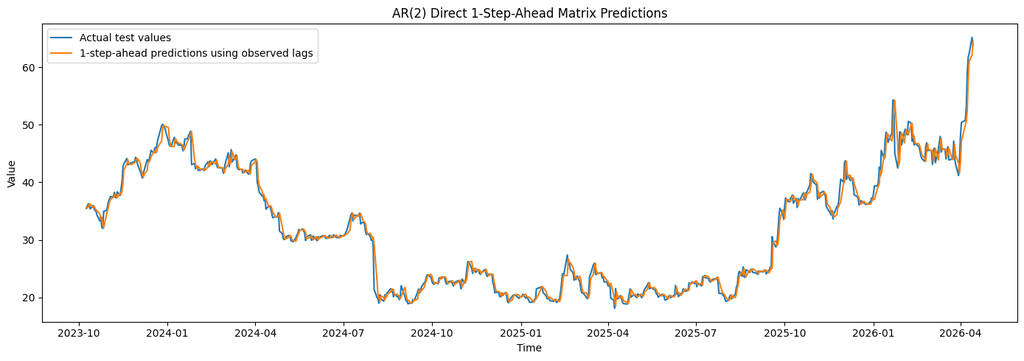

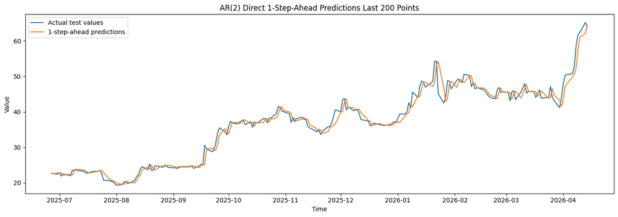

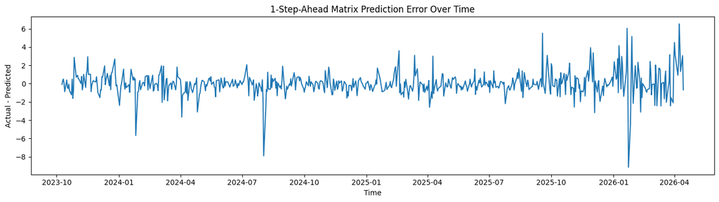

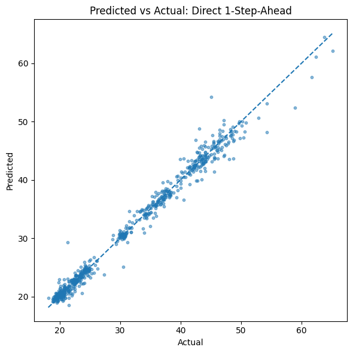

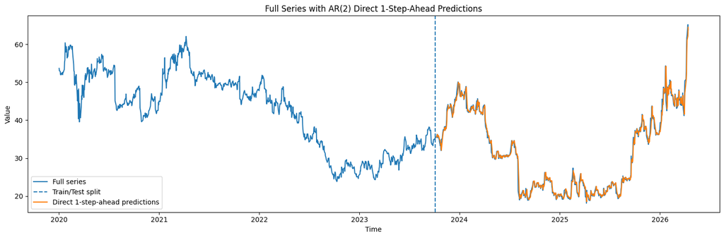

```python
import matplotlib.pyplot as plt
import numpy as np
import math

# --------------------------------------------------
# Choose forecast horizon
# --------------------------------------------------
H = 1   # h-steps ahead

# --------------------------------------------------
# Build h-step-ahead test matrix
# Predict x_{t+H} using [1, x_t, x_{t-1}, ..., x_{t-p+1}]
# --------------------------------------------------
X_test_h_lags = np.column_stack([
    x_test[LAG_ORDER - 1 - i : len(x_test) - H - i]
    for i in range(LAG_ORDER)
])

X_test_h = np.column_stack([np.ones(len(X_test_h_lags)), X_test_h_lags])

x_test_h_slice = x_test[LAG_ORDER - 1 + H:]

# h-step-ahead matrix predictions
x_test_hat_h = X_test_h @ a_hat

# Flatten for plotting safety
x_test_plot = np.asarray(x_test_h_slice).ravel()
x_test_hat_plot = np.asarray(x_test_hat_h).ravel()

# --------------------------------------------------
# Time axis alignment
# --------------------------------------------------
split_idx = math.floor(TRAIN_RATIO * len(x))

try:
    time_axis_full = x_df.index
    time_axis_test = time_axis_full[split_idx + LAG_ORDER - 1 + H:]
except:
    time_axis_full = np.arange(len(x))
    time_axis_test = np.arange(
        split_idx + LAG_ORDER - 1 + H,
        split_idx + LAG_ORDER - 1 + H + len(x_test_plot)
    )

# --------------------------------------------------
# h-step-ahead R^2
# --------------------------------------------------
errors = x_test_plot - x_test_hat_plot
centered_x_test = x_test_plot - np.mean(x_test_plot)

RSS = np.dot(errors, errors)
TSS = np.dot(centered_x_test, centered_x_test)

R_squared_h = 1 - RSS / TSS

print(f"{H}-step-ahead matrix R^2:", R_squared_h)

# --------------------------------------------------
# 1) Actual vs h-step-ahead predictions
# --------------------------------------------------
plt.figure(figsize=(14, 5))
plt.plot(time_axis_test, x_test_plot, label="Actual test values")
plt.plot(time_axis_test, x_test_hat_plot, label=f"{H}-step-ahead predictions using observed lags")
plt.title(f"AR({LAG_ORDER}) Direct {H}-Step-Ahead Matrix Predictions")
plt.xlabel("Time")
plt.ylabel("Value")
plt.legend()
plt.tight_layout()
plt.show()

# --------------------------------------------------
# 2) Zoomed-in view on the last 200 aligned test points
# --------------------------------------------------
k = min(200, len(x_test_plot))

plt.figure(figsize=(14, 5))
plt.plot(time_axis_test[-k:], x_test_plot[-k:], label="Actual test values")
plt.plot(time_axis_test[-k:], x_test_hat_plot[-k:], label=f"{H}-step-ahead predictions")
plt.title(f"AR({LAG_ORDER}) Direct {H}-Step-Ahead Predictions Last {k} Points")
plt.xlabel("Time")
plt.ylabel("Value")
plt.legend()
plt.tight_layout()
plt.show()

# --------------------------------------------------
# 3) Error over time
# --------------------------------------------------
plt.figure(figsize=(14, 4))
plt.plot(time_axis_test, errors)
plt.title(f"{H}-Step-Ahead Matrix Prediction Error Over Time")
plt.xlabel("Time")
plt.ylabel("Actual - Predicted")
plt.tight_layout()
plt.show()

# --------------------------------------------------
# 4) Predicted vs actual scatter
# --------------------------------------------------
plt.figure(figsize=(6, 6))
plt.scatter(x_test_plot, x_test_hat_plot, s=10, alpha=0.5)

mn = min(np.min(x_test_plot), np.min(x_test_hat_plot))
mx = max(np.max(x_test_plot), np.max(x_test_hat_plot))

plt.plot([mn, mx], [mn, mx], linestyle="--")
plt.title(f"Predicted vs Actual: Direct {H}-Step-Ahead")
plt.xlabel("Actual")
plt.ylabel("Predicted")
plt.tight_layout()
plt.show()

# --------------------------------------------------
# 5) Full series with h-step predictions highlighted
# --------------------------------------------------
plt.figure(figsize=(15, 5))

if len(np.shape(x)) > 1:
    x_plot = x.flatten()
else:
    x_plot = x

plt.plot(time_axis_full, x_plot, label="Full series")
plt.axvline(time_axis_full[split_idx], linestyle="--", label="Train/Test split")
plt.plot(time_axis_test, x_test_hat_plot, label=f"Direct {H}-step-ahead predictions")
plt.title(f"Full Series with AR({LAG_ORDER}) Direct {H}-Step-Ahead Predictions")
plt.xlabel("Time")
plt.ylabel("Value")
plt.legend()
plt.tight_layout()
plt.show()
```

## B - Rolling H-Block Recursive Forecast

```
Rolling-origin block recursive forecast R^2, H=50: 0.7312
```

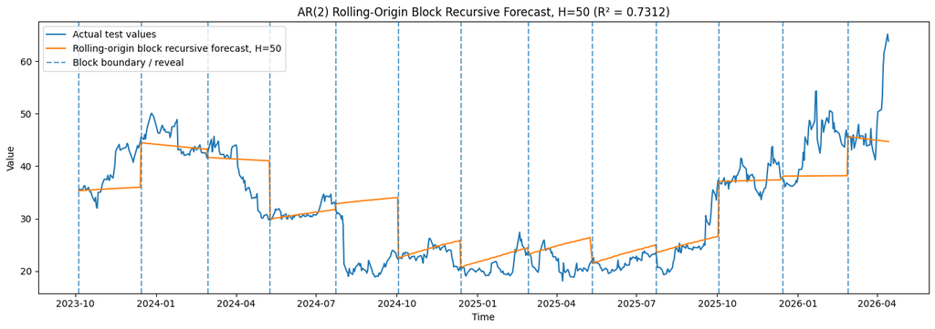

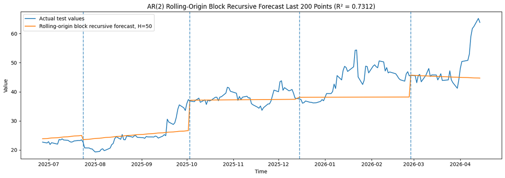

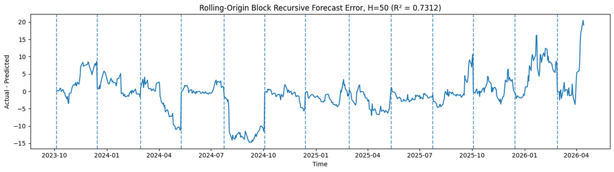

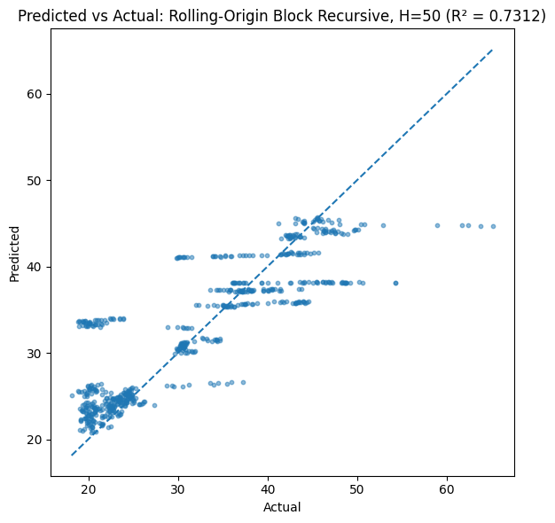

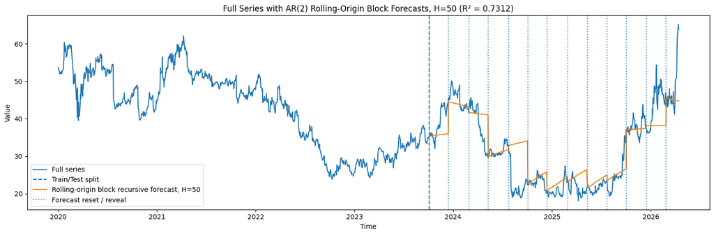

```python
import numpy as np
import matplotlib.pyplot as plt
import math

H = 50  # forecast block size

# Flatten for safety
x_train_flat = np.asarray(x_train).ravel()
x_test_flat = np.asarray(x_test).ravel()
a_hat_flat = np.asarray(a_hat).ravel()

preds = []
actuals = []
pred_indices_inside_test = []

# Store block-start indices inside the test set for vertical lines
block_boundary_indices_inside_test = []

# Start forecasting at the first test point
block_start = 0

while block_start < len(x_test_flat):

    block_boundary_indices_inside_test.append(block_start)

    # True history available at forecast origin:
    # all training data + revealed test data up to this block boundary.
    history = list(np.concatenate([
        x_train_flat,
        x_test_flat[:block_start]
    ]))

    # Forecast up to H steps recursively
    block_preds = []
    steps_this_block = min(H, len(x_test_flat) - block_start)

    for step in range(steps_this_block):
        lag_values = np.array([
            history[-1 - i]
            for i in range(LAG_ORDER)
        ], dtype=float).ravel()
        lag_vector = np.concatenate(([1.0], lag_values))

        next_pred = np.dot(lag_vector, a_hat_flat)
        block_preds.append(next_pred)

        # Recursive feeding within the block
        history.append(next_pred)

    # Store predictions and corresponding true future values
    preds.extend(block_preds)
    actuals.extend(x_test_flat[block_start : block_start + steps_this_block])
    pred_indices_inside_test.extend(
        range(block_start, block_start + steps_this_block)
    )

    # Reveal true values through this block, then move ahead by H
    block_start += H

preds = np.asarray(preds)
actuals = np.asarray(actuals)
pred_indices_inside_test = np.asarray(pred_indices_inside_test)
block_boundary_indices_inside_test = np.asarray(block_boundary_indices_inside_test)

# ----------------------------------------
# R^2
# ----------------------------------------
errors = actuals - preds
centered_actuals = actuals - np.mean(actuals)

RSS = np.dot(errors, errors)
TSS = np.dot(centered_actuals, centered_actuals)

R_squared_block_recursive = 1 - RSS / TSS
print(f"Rolling-origin block recursive forecast R^2, H={H}: {R_squared_block_recursive:.4f}")

# ----------------------------------------
# Time axes
# ----------------------------------------
split_idx = math.floor(TRAIN_RATIO * len(x))

try:
    time_axis_full = x_df.index
    time_axis_forecast = time_axis_full[split_idx + pred_indices_inside_test]
    block_boundary_times = time_axis_full[split_idx + block_boundary_indices_inside_test]
except:
    time_axis_full = np.arange(len(x))
    time_axis_forecast = split_idx + pred_indices_inside_test
    block_boundary_times = split_idx + block_boundary_indices_inside_test

# ----------------------------------------
# 1) Actual vs rolling-origin block recursive predictions
# ----------------------------------------
plt.figure(figsize=(14, 5))
plt.plot(time_axis_forecast, actuals, label="Actual test values")
plt.plot(time_axis_forecast, preds, label=f"Rolling-origin block recursive forecast, H={H}")

for j, tline in enumerate(block_boundary_times):
    if j == 0:
        plt.axvline(tline, linestyle="--", alpha=0.7, label="Block boundary / reveal")
    else:
        plt.axvline(tline, linestyle="--", alpha=0.7)

plt.title(
    f"AR({LAG_ORDER}) Rolling-Origin Block Recursive Forecast, H={H} "
    f"(R² = {R_squared_block_recursive:.4f})"
)
plt.xlabel("Time")
plt.ylabel("Value")
plt.legend()
plt.tight_layout()
plt.show()

# ----------------------------------------
# 2) Zoomed-in view on last 200 forecasted points
# ----------------------------------------
k = min(200, len(actuals))

plt.figure(figsize=(14, 5))
plt.plot(time_axis_forecast[-k:], actuals[-k:], label="Actual test values")
plt.plot(time_axis_forecast[-k:], preds[-k:], label=f"Rolling-origin block recursive forecast, H={H}")

zoom_start = time_axis_forecast[-k]
zoom_end = time_axis_forecast[-1]

for j, tline in enumerate(block_boundary_times):
    if zoom_start <= tline <= zoom_end:
        if j == 0:
            plt.axvline(tline, linestyle="--", alpha=0.7, label="Block boundary / reveal")
        else:
            plt.axvline(tline, linestyle="--", alpha=0.7)

plt.title(
    f"AR({LAG_ORDER}) Rolling-Origin Block Recursive Forecast Last {k} Points "
    f"(R² = {R_squared_block_recursive:.4f})"
)
plt.xlabel("Time")
plt.ylabel("Value")
plt.legend()
plt.tight_layout()
plt.show()

# ----------------------------------------
# 3) Error over time
# ----------------------------------------
plt.figure(figsize=(14, 4))
plt.plot(time_axis_forecast, errors)

for tline in block_boundary_times:
    plt.axvline(tline, linestyle="--", alpha=0.7)

plt.title(
    f"Rolling-Origin Block Recursive Forecast Error, H={H} "
    f"(R² = {R_squared_block_recursive:.4f})"
)
plt.xlabel("Time")
plt.ylabel("Actual - Predicted")
plt.tight_layout()
plt.show()

# ----------------------------------------
# 4) Predicted vs actual scatter
# ----------------------------------------
plt.figure(figsize=(6, 6))
plt.scatter(actuals, preds, s=10, alpha=0.5)

mn = min(np.min(actuals), np.min(preds))
mx = max(np.max(actuals), np.max(preds))
plt.plot([mn, mx], [mn, mx], linestyle="--")

plt.title(
    f"Predicted vs Actual: Rolling-Origin Block Recursive, H={H} "
    f"(R² = {R_squared_block_recursive:.4f})"
)
plt.xlabel("Actual")
plt.ylabel("Predicted")
plt.tight_layout()
plt.show()

# ----------------------------------------
# 5) Full series with block forecasts highlighted
# ----------------------------------------
x_plot = np.asarray(x).ravel()

plt.figure(figsize=(15, 5))
plt.plot(time_axis_full, x_plot, label="Full series")
plt.axvline(time_axis_full[split_idx], linestyle="--", label="Train/Test split")
plt.plot(time_axis_forecast, preds, label=f"Rolling-origin block recursive forecast, H={H}")

for j, tline in enumerate(block_boundary_times):
    if j == 0:
        plt.axvline(tline, linestyle=":", alpha=0.8, label="Forecast reset / reveal")
    else:
        plt.axvline(tline, linestyle=":", alpha=0.8)

plt.title(
    f"Full Series with AR({LAG_ORDER}) Rolling-Origin Block Forecasts, H={H} "
    f"(R² = {R_squared_block_recursive:.4f})"
)
plt.xlabel("Time")
plt.ylabel("Value")
plt.legend()
plt.tight_layout()
plt.show()
```

## C - Free-running Recursive Forecast

```
Free-running recursive forecast R^2: -0.3733938243899848
```

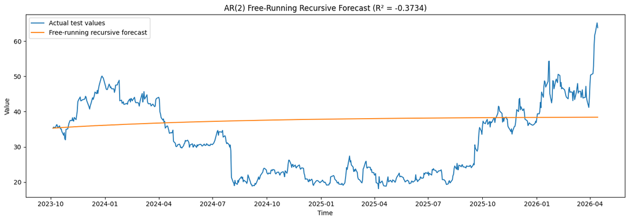

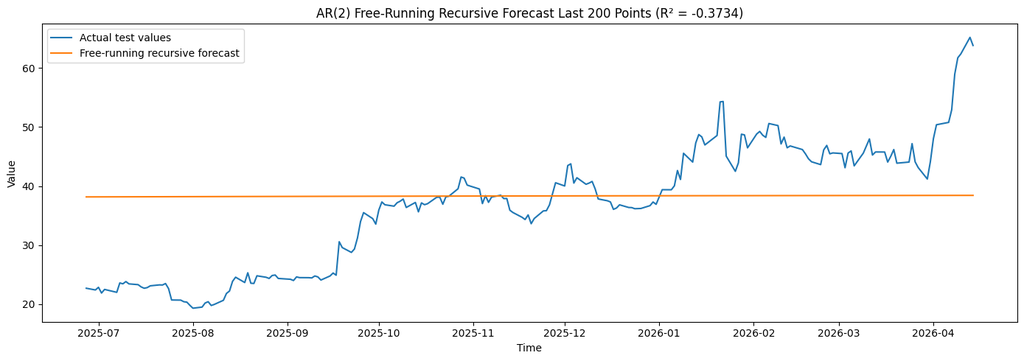

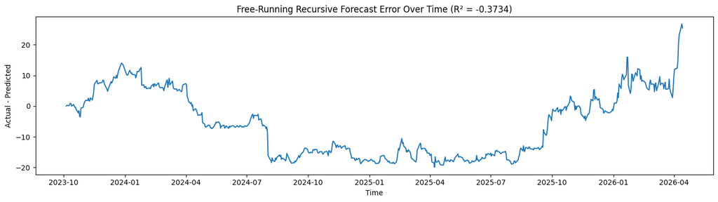

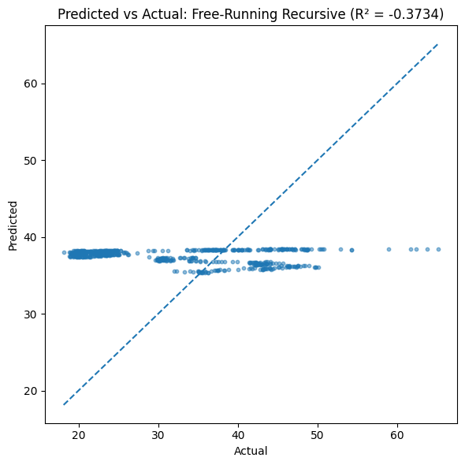

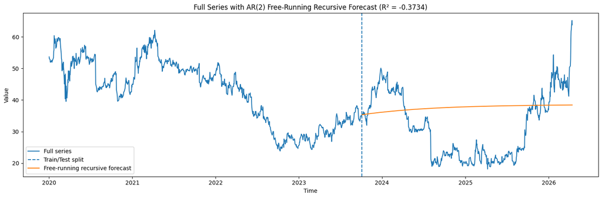

```python
import matplotlib.pyplot as plt
import numpy as np
import math

# --------------------------------------------------
# True free-running recursive forecast
# --------------------------------------------------
# Seed once using the last LAG_ORDER values from the training set.
# Then forecast through the entire test set by feeding predictions back into the model.
# No true test values are used after initialization.

x_train_flat = np.asarray(x_train).ravel()
x_test_flat = np.asarray(x_test).ravel()
a_hat_flat = np.asarray(a_hat).ravel()

history = list(x_train_flat[-LAG_ORDER:])
x_test_hat_free = []

for t in range(len(x_test_flat)):
    lag_values = np.array([
        history[-1 - i]
        for i in range(LAG_ORDER)
    ], dtype=float).ravel()
    lag_vector = np.concatenate(([1.0], lag_values))

    next_pred = np.dot(lag_vector, a_hat_flat)
    x_test_hat_free.append(next_pred)

    # Crucial: feed the prediction back in, not the true test value
    history.append(next_pred)

x_test_hat_free = np.asarray(x_test_hat_free)

# Flatten for plotting safety
x_test_plot = np.asarray(x_test_flat).ravel()
x_test_hat_plot = np.asarray(x_test_hat_free).ravel()

# --------------------------------------------------
# Time axis alignment
# --------------------------------------------------
split_idx = math.floor(TRAIN_RATIO * len(x))

try:
    time_axis_full = x_df.index
    time_axis_test = time_axis_full[split_idx : split_idx + len(x_test_plot)]
except:
    time_axis_full = np.arange(len(x))
    time_axis_test = np.arange(
        split_idx,
        split_idx + len(x_test_plot)
    )

# --------------------------------------------------
# Free-running recursive R^2
# --------------------------------------------------
errors = x_test_plot - x_test_hat_plot
centered_x_test = x_test_plot - np.mean(x_test_plot)

RSS = np.dot(errors, errors)
TSS = np.dot(centered_x_test, centered_x_test)

R_squared_free = 1 - RSS / TSS

print(f"Free-running recursive forecast R^2: {R_squared_free}")

# --------------------------------------------------
# 1) Actual vs free-running recursive predictions
# --------------------------------------------------
plt.figure(figsize=(14, 5))
plt.plot(time_axis_test, x_test_plot, label="Actual test values")
plt.plot(time_axis_test, x_test_hat_plot, label="Free-running recursive forecast")
plt.title(
    f"AR({LAG_ORDER}) Free-Running Recursive Forecast "
    f"(R² = {R_squared_free:.4f})"
)
plt.xlabel("Time")
plt.ylabel("Value")
plt.legend()
plt.tight_layout()
plt.show()

# --------------------------------------------------
# 2) Zoomed-in view on the last 200 test points
# --------------------------------------------------
k = min(200, len(x_test_plot))

plt.figure(figsize=(14, 5))
plt.plot(time_axis_test[-k:], x_test_plot[-k:], label="Actual test values")
plt.plot(time_axis_test[-k:], x_test_hat_plot[-k:], label="Free-running recursive forecast")
plt.title(
    f"AR({LAG_ORDER}) Free-Running Recursive Forecast Last {k} Points "
    f"(R² = {R_squared_free:.4f})"
)
plt.xlabel("Time")
plt.ylabel("Value")
plt.legend()
plt.tight_layout()
plt.show()

# --------------------------------------------------
# 3) Error over time
# --------------------------------------------------
plt.figure(figsize=(14, 4))
plt.plot(time_axis_test, errors)
plt.title(
    f"Free-Running Recursive Forecast Error Over Time "
    f"(R² = {R_squared_free:.4f})"
)
plt.xlabel("Time")
plt.ylabel("Actual - Predicted")
plt.tight_layout()
plt.show()

# --------------------------------------------------
# 4) Predicted vs actual scatter
# --------------------------------------------------
plt.figure(figsize=(6, 6))
plt.scatter(x_test_plot, x_test_hat_plot, s=10, alpha=0.5)

mn = min(np.min(x_test_plot), np.min(x_test_hat_plot))
mx = max(np.max(x_test_plot), np.max(x_test_hat_plot))

plt.plot([mn, mx], [mn, mx], linestyle="--")
plt.title(
    f"Predicted vs Actual: Free-Running Recursive "
    f"(R² = {R_squared_free:.4f})"
)
plt.xlabel("Actual")
plt.ylabel("Predicted")
plt.tight_layout()
plt.show()

# --------------------------------------------------
# 5) Full series with free-running predictions highlighted
# --------------------------------------------------
plt.figure(figsize=(15, 5))

if len(np.shape(x)) > 1:
    x_plot = x.flatten()
else:
    x_plot = x

plt.plot(time_axis_full, x_plot, label="Full series")
plt.axvline(time_axis_full[split_idx], linestyle="--", label="Train/Test split")
plt.plot(time_axis_test, x_test_hat_plot, label="Free-running recursive forecast")

plt.title(
    f"Full Series with AR({LAG_ORDER}) Free-Running Recursive Forecast "
    f"(R² = {R_squared_free:.4f})"
)
plt.xlabel("Time")
plt.ylabel("Value")
plt.legend()
plt.tight_layout()
plt.show()
```

## 4 - Confidence Intervals for $AR(p)$ Inference

### 4.1 Normality Assumption

Assume: $$ \epsilon \sim \mathcal{N}(0, \sigma^2 I) $$

Then: $$ \hat{a} = (X^T X)^{-1} X^T x \sim \mathcal{N}\left(a, \ \sigma^2 (X^T X)^{-1}\right) $$

### 4.2 Variance Estimation

Estimate noise variance: $$ \hat{\sigma}^2 = \frac{1}{n - p} \|x - X\hat{a}\|^2 $$

Thus: $$ \mathrm{Var}(\hat{a}) \approx \hat{\sigma}^2 (X^T X)^{-1} $$

### 4.3 Confidence Intervals for Coefficients

For each $i$: $$ \hat{a}_i \sim \mathcal{N}\left(a_i, \ \hat{\sigma}^2 [(X^T X)^{-1}]_{ii}\right) $$

Confidence interval: $$ \hat{a}_i \ \pm \ z_{\alpha/2} \cdot \sqrt{\hat{\sigma}^2 [(X^T X)^{-1}]_{ii}} $$

For finite samples, replace $z_{\alpha/2}$ with $t_{\alpha/2,\, n-p}$.

### 4.4 Confidence Interval for Prediction

Let: $$ x_t^{(lag)} = [x_{t-1}, \dots, x_{t-p}] $$

Then: $$ \hat{x}_t = x_t^{(lag)} \hat{a} $$

and: $$ \mathrm{Var}(\hat{x}_t) = \hat{\sigma}^2 \left(1 + x_t^{(lag)} (X^T X)^{-1} (x_t^{(lag)})^T \right) $$

Thus: $$ \hat{x}_t \ \pm \ z_{\alpha/2} \cdot \sqrt{\hat{\sigma}^2 \left(1 + x_t^{(lag)} (X^T X)^{-1} (x_t^{(lag)})^T \right)} $$

```python
import numpy as np
import pandas as pd
from scipy.stats import t

# --------------------------------------------------
# 4.1 Normality assumption + coefficient distribution
# --------------------------------------------------
# Assumption:
#     epsilon ~ N(0, sigma^2 I)
#
# Then:
#     a_hat ~ N(a, sigma^2 (X^T X)^(-1))

X = np.asarray(X_train)
y = np.asarray(x_train_slice).ravel()
a_hat = np.asarray(a_hat).ravel()

n = len(y)
p = X.shape[1]

coef_names = ["a_0"] + [f"a_{i}" for i in range(1, p)]

# Fitted values and residuals
y_hat = X @ a_hat
epsilon_hat = y - y_hat

# --------------------------------------------------
# 4.2 Variance estimation
# --------------------------------------------------
# sigma_hat^2 = RSS / (n - p)

RSS = np.dot(epsilon_hat, epsilon_hat)
sigma2_hat = RSS / (n - p)
sigma_hat = np.sqrt(sigma2_hat)

XtX_inv = np.linalg.inv(X.T @ X)

# Estimated covariance matrix of a_hat
cov_a_hat = sigma2_hat * XtX_inv

cov_a_hat_df = pd.DataFrame(
    cov_a_hat,
    index=coef_names,
    columns=coef_names
)

print("Estimated sigma^2:", sigma2_hat)
print("Estimated sigma:", sigma_hat)
print("Estimated covariance matrix of a_hat:")
display(cov_a_hat_df)

# --------------------------------------------------
# 4.3 Confidence intervals for coefficients
# --------------------------------------------------

ALPHA = 0.05
df = n - p

t_crit = t.ppf(1 - ALPHA / 2, df=df)

coef_se = np.sqrt(np.diag(cov_a_hat))

coef_lower = a_hat - t_crit * coef_se
coef_upper = a_hat + t_crit * coef_se

coef_ci_df = pd.DataFrame({
    "Coefficient": coef_names,
    "Estimate": a_hat,
    "Std_Error": coef_se,
    "CI_Lower": coef_lower,
    "CI_Upper": coef_upper,
})

display(coef_ci_df)

print(f"t critical value with df={df}: {t_crit:.4f}")
```

```
Estimated sigma^2: 1.2512420433922455
Estimated sigma: 1.1185893095288573
Estimated covariance matrix of a_hat:
```

|  | a_0 | a_1 | a_2 |
| --- | --- | --- | --- |
| a_0 | 0.025581 | -0.000280 | -0.000289 |
| a_1 | -0.000280 | 0.001022 | -0.001015 |
| a_2 | -0.000289 | -0.001015 | 0.001022 |

|  | Coefficient | Estimate | Std_Error | CI_Lower | CI_Upper |
| --- | --- | --- | --- | --- | --- |
| 0 | a_0 | 0.217778 | 0.159941 | -0.096105 | 0.531661 |
| 1 | a_1 | 0.800089 | 0.031974 | 0.737341 | 0.862838 |
| 2 | a_2 | 0.194266 | 0.031963 | 0.131540 | 0.256993 |

```
t critical value with df=941: 1.9625
```

## 5 - Stationarity Condition

The characteristic polynomial for the $AR(p)$ process is the following: $$\phi(z) = 1-a_1 z - a_2 z^2 - \dots - a_p z^p$$ By a theorem, the process is stationariy if and only if $$\forall z, \ (\phi(z) = 0 \implies | z | > 1) .$$

That is, verifying stationarity is equivalent to verifying that all roots of the characteristic polynomial lie outside the unit circle.

(Note: the stationarity referred to here is weak stationarity.)

## Testing Stationarity

### 5.1 - Stationarity Robustness via Bootstrap

Since the coefficients are estimated from data, it is not enough to check stationarity only for the point estimate $\hat{a}$. To assess robustness, we bootstrap the coefficient estimates and test whether the resulting characteristic polynomials remain stationary.

Using the asymptotic normal approximation, $$ \hat{a} \approx \mathcal{N}\left(a,\hat{\sigma}^2 (X^T X)^{-1}\right), $$ we generate bootstrap samples $$ a^{(1)},a^{(2)},\dots,a^{(B)} \sim \mathcal{N}\left(\hat{a},\hat{\sigma}^2 (X^T X)^{-1}\right). $$

For each bootstrap sample $a^{(b)} = (a_1^{(b)},\dots,a_p^{(b)})$, define the corresponding characteristic polynomial $$ \phi^{(b)}(z) = 1-a_1^{(b)} z-a_2^{(b)} z^2-\dots-a_p^{(b)} z^p. $$

Then test whether all roots of $\phi^{(b)}(z)$ lie outside the unit circle: $$ \forall z,\ (\phi^{(b)}(z)=0 \implies |z|>1). $$

Define the stationarity indicator $$ I^{(b)} = \begin{cases} 1, & \text{if all roots of } \phi^{(b)}(z) \text{ satisfy } |z|>1,\\ 0, & \text{otherwise.} \end{cases} $$

The bootstrap stationarity score is then $$ \hat{p}_{\mathrm{stat}} = \frac{1}{B}\sum_{b=1}^B I^{(b)}. $$

This quantity estimates the proportion of plausible coefficient vectors, under the sampling uncertainty of $\hat{a}$, that produce a stationary $AR(p)$ process.

### 5.2 - Interpretation

- If $\hat{p}_{\mathrm{stat}} \approx 1$, then stationarity is robust.
- If $\hat{p}_{\mathrm{stat}}$ is close to $0$, then the fitted model is not robustly stationary.
- Intermediate values indicate that the estimated process lies near the boundary of stationarity.

Thus, the bootstrap procedure gives a practical measure of how sensitive the stationarity conclusion is to estimation uncertainty.

### 5.3 - Decision Rule via Significance Level

Let $\hat{p}_{\mathrm{stat}}$ denote the bootstrap estimate of the probability that the process is stationary.

Fix a significance level $\alpha \in (0,1)$.

We reject stationarity if $$ \hat{p}_{\mathrm{stat}} < 1 - \alpha, $$ i.e. if the probability of non-stationarity exceeds $\alpha$.

Equivalently, we accept stationarity only if the estimated parameter uncertainty places at least $(1-\alpha)$ mass inside the stationary region.

```
Point estimate AR coefficients: [0.80008915 0.19426646]
Point estimate stationary: True
Estimated sigma^2: 1.2472656385933296
Bootstrap stationarity proportion: 0.9356
Decision at alpha = 0.05 : Reject stationarity
```

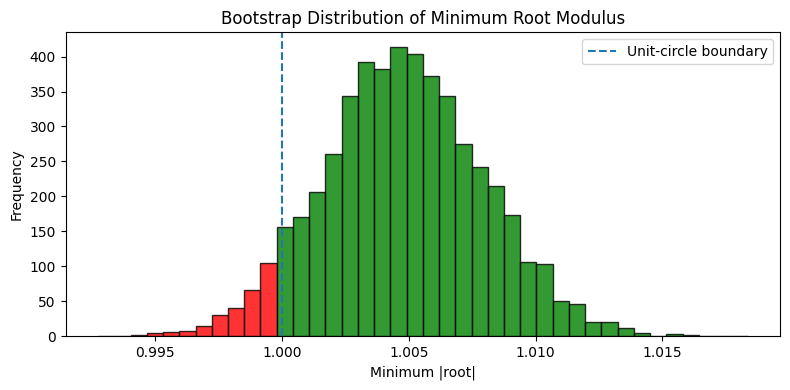

```python
# Bootstrap-based stationarity robustness
B = 5000
ALPHA = 0.05
RNG_SEED = 42

epsilon_train_hat = x_train_slice - x_train_hat
sigma2_hat = np.dot(epsilon_train_hat, epsilon_train_hat) / len(x_train_slice)

XtX_inv = np.linalg.inv(np.matmul(X_train.T, X_train))
cov_a_hat = sigma2_hat * XtX_inv

rng = np.random.default_rng(RNG_SEED)

# Stationarity depends on the AR lag coefficients only, not the intercept.
a_hat_ar = np.asarray(a_hat).ravel()[1:]
cov_a_hat_ar = cov_a_hat[1:, 1:]

a_boot = rng.multivariate_normal(mean=a_hat_ar, cov=cov_a_hat_ar, size=B)

def is_stationary_ar(coeffs):
    poly_coeffs = np.concatenate((-np.array(coeffs)[::-1], np.array([1.0])))
    roots = np.roots(poly_coeffs)
    return np.all(np.abs(roots) > 1), roots

point_estimate_stationary, point_roots = is_stationary_ar(a_hat_ar)

stationary_flags = np.zeros(B, dtype=int)
min_root_modulus = np.zeros(B)

for b in range(B):
    is_stat, roots = is_stationary_ar(a_boot[b])
    stationary_flags[b] = int(is_stat)
    min_root_modulus[b] = np.min(np.abs(roots))

p_stat_hat = stationary_flags.mean()

print("Point estimate AR coefficients:", a_hat_ar)
print("Point estimate stationary:", point_estimate_stationary)
print("Estimated sigma^2:", sigma2_hat)
print("Bootstrap stationarity proportion:", p_stat_hat)
print("Decision at alpha =", ALPHA, ":", "Accept stationarity" if p_stat_hat >= 1 - ALPHA else "Reject stationarity")

# --------------------------------------------------
# Colored histogram: red below 1, green above 1
# --------------------------------------------------
counts, bin_edges = np.histogram(min_root_modulus, bins=40)
bin_centers = 0.5 * (bin_edges[:-1] + bin_edges[1:])
bin_widths = np.diff(bin_edges)

plt.figure(figsize=(8, 4))

for i in range(len(counts)):
    color = "green" if bin_centers[i] > 1.0 else "red"
    plt.bar(
        bin_edges[i],
        counts[i],
        width=bin_widths[i],
        align="edge",
        color=color,
        edgecolor="black",
        alpha=0.8
    )

plt.axvline(1.0, linestyle="--", label="Unit-circle boundary")
plt.title("Bootstrap Distribution of Minimum Root Modulus")
plt.xlabel("Minimum |root|")
plt.ylabel("Frequency")
plt.legend()
plt.tight_layout()
plt.show()
```

## 6 - Generate a Stock AR Analysis Report

```python
# ============================================================
# AR Stock PDF Report Generator
# Up to stationarity analysis
# ============================================================

import os
import math
import tempfile
from datetime import datetime

import numpy as np
import pandas as pd
import matplotlib.pyplot as plt

from scipy.stats import t
from statsmodels.tsa.stattools import pacf

from reportlab.lib import colors
from reportlab.lib.pagesizes import letter
from reportlab.lib.styles import getSampleStyleSheet, ParagraphStyle
from reportlab.lib.units import inch
from reportlab.platypus import (
    SimpleDocTemplate,
    Paragraph,
    Spacer,
    Image,
    Table,
    TableStyle,
    PageBreak,
)


# ============================================================
# Helper: AR design matrix
# ============================================================

def build_ar_design(series, p):
    """
    Build constant-mean AR(p) regression design matrix.

    Model:
        x_t = a_0 + a_1 x_{t-1} + ... + a_p x_{t-p} + epsilon_t

    Returns:
        X_p: intercept + lag matrix
        y_p: aligned target vector
    """
    series = np.asarray(series).ravel()

    X_lags = np.column_stack([
        series[p - 1 - i : len(series) - 1 - i]
        for i in range(p)
    ])

    X_p = np.column_stack([np.ones(len(X_lags)), X_lags])

    y_p = series[p:]

    return X_p, y_p


def fit_ar_ols(x_train, p):
    """
    Fit constant-mean AR(p) by least squares.
    """
    X_train, y_train = build_ar_design(x_train, p)

    # More numerically stable than explicit inverse
    a_hat = np.linalg.lstsq(X_train, y_train, rcond=None)[0]

    y_hat = X_train @ a_hat
    residuals = y_train - y_hat

    return {
        "X_train": X_train,
        "y_train": y_train,
        "a_hat": a_hat,
        "y_hat": y_hat,
        "residuals": residuals,
    }


def r2_score(y_true, y_pred):
    """
    Standard R^2.
    """
    y_true = np.asarray(y_true).ravel()
    y_pred = np.asarray(y_pred).ravel()

    rss = np.dot(y_true - y_pred, y_true - y_pred)
    tss = np.dot(y_true - np.mean(y_true), y_true - np.mean(y_true))

    return 1 - rss / tss


# ============================================================
# PACF + AIC/BIC + Train-Ratio Selection
# ============================================================

def select_train_ratio_and_lag(
    x,
    train_ratio_candidates=(0.50, 0.60, 0.70, 0.80),
    max_lag=30,
    pacf_buffer=5,
    selection_rule="bic_then_validation_r2",
):
    """
    Jointly search over train ratios and AR lag orders.

    For each train ratio:
        1. Compute PACF on training data.
        2. Use significant PACF lags to define max candidate lag.
        3. Fit AR(p) models.
        4. Compute AIC/BIC on training data.
        5. Compute one-step observed-lag R^2 on test data.

    Final default rule:
        - For each train ratio, take BIC-best lag.
        - Among those, choose best one-step test R^2.
    """
    x = np.asarray(x).ravel()

    selection_rows = []
    pacf_records = {}

    for train_ratio in train_ratio_candidates:
        split_idx = math.floor(train_ratio * len(x))
        x_train = x[:split_idx]
        x_test = x[split_idx:]

        if len(x_train) <= max_lag + 5 or len(x_test) <= max_lag + 5:
            continue

        # -----------------------------
        # PACF for this training split
        # -----------------------------
        pacf_values = pacf(x_train, nlags=max_lag, method="ywm")
        n_train = len(x_train)
        threshold = 1.96 / np.sqrt(n_train)
        lags = np.arange(len(pacf_values))

        significant_lags = lags[
            (np.abs(pacf_values) > threshold) & (lags > 0)
        ]

        if len(significant_lags) > 0:
            pacf_suggested_lag = int(significant_lags.max())
        else:
            pacf_suggested_lag = 1

        pacf_informed_max_lag = min(
            max_lag,
            max(5, pacf_suggested_lag + pacf_buffer)
        )

        pacf_records[train_ratio] = {
            "split_idx": split_idx,
            "x_train": x_train,
            "x_test": x_test,
            "pacf_values": pacf_values,
            "threshold": threshold,
            "lags": lags,
            "significant_lags": significant_lags,
            "PACF_SUGGESTED_LAG": pacf_suggested_lag,
            "PACF_INFORMED_MAX_LAG": pacf_informed_max_lag,
        }

        # -----------------------------
        # AIC/BIC over candidate lags
        # -----------------------------
        for p in range(1, pacf_informed_max_lag + 1):

            if len(x_train) <= p + 1 or len(x_test) <= p + 1:
                continue

            X_train_p, y_train_p = build_ar_design(x_train, p)
            X_test_p, y_test_p = build_ar_design(x_test, p)

            a_hat_p = np.linalg.lstsq(X_train_p, y_train_p, rcond=None)[0]

            y_train_hat_p = X_train_p @ a_hat_p
            y_test_hat_p = X_test_p @ a_hat_p

            train_resid_p = y_train_p - y_train_hat_p
            test_resid_p = y_test_p - y_test_hat_p

            RSS_train_p = np.dot(train_resid_p, train_resid_p)
            RSS_test_p = np.dot(test_resid_p, test_resid_p)

            n_p = len(y_train_p)
            k_p = X_train_p.shape[1]

            sigma2_hat_p = RSS_train_p / n_p

            AIC_p = n_p * np.log(sigma2_hat_p) + 2 * k_p
            BIC_p = n_p * np.log(sigma2_hat_p) + k_p * np.log(n_p)

            Test_R2_OneStep_p = r2_score(y_test_p, y_test_hat_p)

            selection_rows.append({
                "Train_Ratio": train_ratio,
                "Train_Size": len(x_train),
                "Test_Size": len(x_test),
                "PACF_Suggested_Lag": pacf_suggested_lag,
                "PACF_Informed_Max_Lag": pacf_informed_max_lag,
                "Lag_Order": p,
                "RSS_Train": RSS_train_p,
                "RSS_Test": RSS_test_p,
                "Sigma2_hat": sigma2_hat_p,
                "AIC": AIC_p,
                "BIC": BIC_p,
                "Test_R2_OneStep": Test_R2_OneStep_p,
            })
```

```python
    selection_df = pd.DataFrame(selection_rows)

    if selection_df.empty:
        raise ValueError("No valid train-ratio / lag-order combinations were found.")

    aic_best_by_ratio = (
        selection_df
        .sort_values(["Train_Ratio", "AIC"])
        .groupby("Train_Ratio")
        .head(1)
        .reset_index(drop=True)
    )

    bic_best_by_ratio = (
        selection_df
        .sort_values(["Train_Ratio", "BIC"])
        .groupby("Train_Ratio")
        .head(1)
        .reset_index(drop=True)
    )

    if selection_rule == "bic_then_validation_r2":
        best_row = bic_best_by_ratio.loc[
            bic_best_by_ratio["Test_R2_OneStep"].idxmax()
        ]
    elif selection_rule == "aic_then_validation_r2":
        best_row = aic_best_by_ratio.loc[
            aic_best_by_ratio["Test_R2_OneStep"].idxmax()
        ]
    elif selection_rule == "global_best_test_r2":
        best_row = selection_df.loc[
            selection_df["Test_R2_OneStep"].idxmax()
        ]
    else:
        raise ValueError(f"Unknown selection_rule: {selection_rule}")

    train_ratio = float(best_row["Train_Ratio"])
    lag_order = int(best_row["Lag_Order"])

    return {
        "selection_df": selection_df,
        "aic_best_by_ratio": aic_best_by_ratio,
        "bic_best_by_ratio": bic_best_by_ratio,
        "pacf_records": pacf_records,
        "best_row": best_row,
        "TRAIN_RATIO": train_ratio,
        "LAG_ORDER": lag_order,
    }


# ============================================================
# Inference
# ============================================================

def compute_ar_inference(x_train, p, alpha=0.05):
    """
    Compute coefficient covariance, standard errors, and confidence intervals.
    """
    fit = fit_ar_ols(x_train, p)

    X = fit["X_train"]
    y = fit["y_train"]
    a_hat = fit["a_hat"]
    residuals = fit["residuals"]

    n = len(y)
    k = X.shape[1]
    df = n - k

    RSS = np.dot(residuals, residuals)
    sigma2_hat = RSS / df
    sigma_hat = np.sqrt(sigma2_hat)

    XtX_inv = np.linalg.pinv(X.T @ X)
    cov_a_hat = sigma2_hat * XtX_inv

    t_crit = t.ppf(1 - alpha / 2, df=df)

    coef_names = ["a_0"] + [f"a_{i}" for i in range(1, k)]
    coef_se = np.sqrt(np.diag(cov_a_hat))

    coef_ci_df = pd.DataFrame({
        "Coefficient": coef_names,
        "Estimate": a_hat,
        "Std_Error": coef_se,
        "CI_Lower": a_hat - t_crit * coef_se,
        "CI_Upper": a_hat + t_crit * coef_se,
    })

    cov_df = pd.DataFrame(
        cov_a_hat,
        index=coef_names,
        columns=coef_names
    )

    return {
        **fit,
        "n": n,
        "p": k,
        "df": df,
        "RSS": RSS,
        "sigma2_hat": sigma2_hat,
        "sigma_hat": sigma_hat,
        "XtX_inv": XtX_inv,
        "cov_a_hat": cov_a_hat,
        "cov_df": cov_df,
        "t_crit": t_crit,
        "coef_ci_df": coef_ci_df,
    }


# ============================================================
# Stationarity
# ============================================================

def ar_roots(coeffs):
    """
    For constant-mean AR(p), coeffs are lag coefficients only:
        x_t = a_0 + a_1 x_{t-1} + ... + a_p x_{t-p} + epsilon_t

    Stationarity requires roots of
        1 - a_1 z - ... - a_p z^p = 0
    to satisfy |z| > 1.
    """
    coeffs = np.asarray(coeffs).ravel()
    poly_coeffs = np.concatenate((-coeffs[::-1], np.array([1.0])))
    roots = np.roots(poly_coeffs)
    return roots


def is_stationary_ar(coeffs):
    roots = ar_roots(coeffs)
    return bool(np.all(np.abs(roots) > 1)), roots


def bootstrap_stationarity(
    a_hat,
    cov_a_hat,
    B=5000,
    seed=42,
    include_intercept=True,
):
    """
    Bootstrap coefficient uncertainty using asymptotic normal approximation:
        a_boot ~ N(a_hat, cov_a_hat)

    Stationarity is computed from AR lag coefficients only.
    """
    rng = np.random.default_rng(seed)

    a_hat = np.asarray(a_hat).ravel()
    cov_a_hat = np.asarray(cov_a_hat)

    if include_intercept:
        a_hat_stationarity = a_hat[1:]
        cov_a_hat_stationarity = cov_a_hat[1:, 1:]
    else:
        a_hat_stationarity = a_hat
        cov_a_hat_stationarity = cov_a_hat

    # Small diagonal jitter for numerical safety
    jitter = 1e-12 * np.eye(len(a_hat_stationarity))
    cov_safe = cov_a_hat_stationarity + jitter

    a_boot = rng.multivariate_normal(
        mean=a_hat_stationarity,
        cov=cov_safe,
        size=B
    )

    stationary_flags = np.zeros(B, dtype=int)
    min_root_modulus = np.zeros(B)

    for b in range(B):
        is_stat, roots = is_stationary_ar(a_boot[b])
        stationary_flags[b] = int(is_stat)
        min_root_modulus[b] = np.min(np.abs(roots))

    point_stationary, point_roots = is_stationary_ar(a_hat_stationarity)

    return {
        "a_boot": a_boot,
        "stationary_flags": stationary_flags,
        "min_root_modulus": min_root_modulus,
        "bootstrap_stationarity_proportion": float(stationary_flags.mean()),
        "point_estimate_stationary": point_stationary,
        "point_roots": point_roots,
        "point_min_root_modulus": float(np.min(np.abs(point_roots))),
    }


# ============================================================
# Plot helpers
# ============================================================

def save_price_plot(x_series, ticker, output_dir):
    path = os.path.join(output_dir, f"{ticker}_price.png")

    plt.figure(figsize=(12, 4))
    plt.plot(x_series.index, x_series.values)
    plt.title(f"{ticker} Adjusted Close / Close Price")
    plt.xlabel("Date")
    plt.ylabel("Price")
    plt.grid(axis="y", alpha=0.25)
    plt.tight_layout()
    plt.savefig(path, dpi=180)
    plt.close()

    return path


def save_pacf_plot(ticker, train_ratio, pacf_record, output_dir):
    path = os.path.join(output_dir, f"{ticker}_pacf.png")

    pacf_values = pacf_record["pacf_values"]
    threshold = pacf_record["threshold"]
    lags = pacf_record["lags"]

    great_lags = np.abs(pacf_values) > threshold
    colors_arr = np.where(great_lags, "green", "royalblue")
```

```python
    plt.figure(figsize=(12, 4.5))

    plt.axhspan(
        -threshold,
        threshold,
        alpha=0.15,
        color="gray",
        label=f"95% confidence band: +/- {threshold:.3f}"
    )

    plt.bar(
        lags,
        pacf_values,
        color=colors_arr,
        alpha=0.85,
        edgecolor="black",
        width=0.8
    )

    plt.axhline(0, linewidth=1)
    plt.xticks(lags, fontsize=8)

    plt.title(f"PACF for {ticker}, Train Ratio = {train_ratio}")
    plt.xlabel("Lag")
    plt.ylabel("Partial Autocorrelation")
    plt.grid(axis="y", alpha=0.25)
    plt.legend()
    plt.tight_layout()
    plt.savefig(path, dpi=180)
    plt.close()

    return path


def save_aic_bic_plot(ticker, train_ratio, selection_df, output_dir):
    path = os.path.join(output_dir, f"{ticker}_aic_bic.png")

    df = selection_df[selection_df["Train_Ratio"] == train_ratio].copy()

    best_by_aic = int(df.loc[df["AIC"].idxmin(), "Lag_Order"])
    best_by_bic = int(df.loc[df["BIC"].idxmin(), "Lag_Order"])

    plt.figure(figsize=(12, 4.5))

    plt.plot(
        df["Lag_Order"],
        df["AIC"],
        marker="o",
        linewidth=2,
        color="tab:blue",
        label="AIC"
    )

    plt.plot(
        df["Lag_Order"],
        df["BIC"],
        marker="s",
        linewidth=2,
        color="tab:orange",
        label="BIC"
    )

    plt.axvline(
        best_by_aic,
        linestyle="--",
        linewidth=1.5,
        color="tab:blue",
        label=f"Best AIC lag = {best_by_aic}"
    )

    plt.axvline(
        best_by_bic,
        linestyle=":",
        linewidth=1.5,
        color="tab:orange",
        label=f"Best BIC lag = {best_by_bic}"
    )

    plt.xticks(df["Lag_Order"])
    plt.xlabel("Lag order p")
    plt.ylabel("Information criterion")
    plt.title(f"AIC and BIC for AR(p) Lag Selection: {ticker}")
    plt.grid(axis="y", alpha=0.25)
    plt.legend()
    plt.tight_layout()
    plt.savefig(path, dpi=180)
    plt.close()

    return path


def save_validation_ratio_plot(ticker, bic_best_by_ratio, selected_train_ratio, output_dir):
    path = os.path.join(output_dir, f"{ticker}_validation_by_ratio.png")

    df = bic_best_by_ratio.sort_values("Train_Ratio").copy()

    plt.figure(figsize=(10, 4.5))

    plt.plot(
        df["Train_Ratio"],
        df["Test_R2_OneStep"],
        marker="o",
        linewidth=2,
        label="BIC-selected one-step test R^2"
    )

    plt.axvline(
        selected_train_ratio,
        linestyle="--",
        linewidth=1.5,
        label=f"Selected train ratio = {selected_train_ratio}"
    )

    for _, row in df.iterrows():
        plt.text(
            row["Train_Ratio"],
            row["Test_R2_OneStep"],
            f"p={int(row['Lag_Order'])}",
            ha="center",
            va="bottom",
            fontsize=8
        )

    plt.xlabel("Train ratio")
    plt.ylabel("One-step test R^2")
    plt.title(f"Validation Performance Across Train Ratios: {ticker}")
    plt.grid(axis="y", alpha=0.25)
    plt.legend()
    plt.tight_layout()
    plt.savefig(path, dpi=180)
    plt.close()

    return path


def save_stationarity_histogram(ticker, stationarity_results, output_dir):
    path = os.path.join(output_dir, f"{ticker}_stationarity_bootstrap.png")

    min_root_modulus = stationarity_results["min_root_modulus"]

    counts, bin_edges = np.histogram(min_root_modulus, bins=40)
    bin_centers = 0.5 * (bin_edges[:-1] + bin_edges[1:])
    bin_widths = np.diff(bin_edges)

    plt.figure(figsize=(10, 4.5))

    for i in range(len(counts)):
        bar_color = "green" if bin_centers[i] > 1.0 else "red"
        plt.bar(
            bin_edges[i],
            counts[i],
            width=bin_widths[i],
            align="edge",
            color=bar_color,
            edgecolor="black",
            alpha=0.8
        )

    plt.axvline(
        1.0,
        linestyle="--",
        linewidth=1.5,
        color="tab:blue",
        label="Unit-circle boundary"
    )

    plt.title(f"Bootstrap Distribution of Minimum Root Modulus: {ticker}")
    plt.xlabel("Minimum |root|")
    plt.ylabel("Frequency")
    plt.legend()
    plt.tight_layout()
    plt.savefig(path, dpi=180)
    plt.close()

    return path


# ============================================================
# ReportLab helpers
# ============================================================

def df_to_reportlab_table(df, max_rows=12, decimals=4):
    """
    Convert a DataFrame to a ReportLab table.
    """
    show_df = df.copy()

    if len(show_df) > max_rows:
        show_df = show_df.head(max_rows)

    # Round numeric columns
    for col in show_df.columns:
        if pd.api.types.is_numeric_dtype(show_df[col]):
            show_df[col] = show_df[col].map(lambda v: f"{v:.{decimals}f}")
        else:
            show_df[col] = show_df[col].astype(str)

    data = [list(show_df.columns)] + show_df.values.tolist()

    table = Table(data, repeatRows=1)

    table.setStyle(TableStyle([
        ("BACKGROUND", (0, 0), (-1, 0), colors.HexColor("#E8E8E8")),
        ("TEXTCOLOR", (0, 0), (-1, 0), colors.black),
        ("GRID", (0, 0), (-1, -1), 0.25, colors.grey),
        ("FONTNAME", (0, 0), (-1, 0), "Helvetica-Bold"),
        ("FONTNAME", (0, 1), (-1, -1), "Helvetica"),
        ("FONTSIZE", (0, 0), (-1, -1), 7),
        ("ALIGN", (0, 0), (-1, -1), "CENTER"),
        ("VALIGN", (0, 0), (-1, -1), "MIDDLE"),
    ]))

    return table


def add_image(story, image_path, width=6.7 * inch):
    """
    Add image scaled to fixed width.
    """
    img = Image(image_path)
    aspect = img.imageHeight / img.imageWidth
    img.drawWidth = width
    img.drawHeight = width * aspect

    story.append(img)
    story.append(Spacer(1, 0.15 * inch))


# ============================================================
# Main report function
# ============================================================

def generate_ar_stock_pdf_report(
    data=None,
    ticker=None,
    x_series=None,
    output_pdf_path=None,
    price_column="Close",
    max_lag=30,
    pacf_buffer=5,
    train_ratio_candidates=(0.50, 0.60, 0.70, 0.80),
    selection_rule="bic_then_validation_r2",
    bootstrap_B=5000,
    bootstrap_seed=42,
    alpha=0.05,
    flags=None,
):
    """
    Generate an AR stock analysis PDF report up to stationarity.
```

```python
    Inputs
    ------
    data:
        Usually a yfinance-style DataFrame.
        Supports:
            data[price_column][ticker]
        or:
            data[ticker]
        depending on shape.
    ticker:
        Stock ticker string.
    x_series:
        Optional pd.Series. If provided, it overrides data/ticker extraction.
    output_pdf_path:
        Path for output PDF.
    flags:
        Dict controlling sections/figures.

    Default flags:
        include_price_plot
        include_selection_tables
        include_pacf_plot
        include_aic_bic_plot
        include_validation_plot
        include_inference
        include_covariance_matrix
        include_stationarity
    """

    default_flags = {
        "include_price_plot": True,
        "include_selection_tables": True,
        "include_pacf_plot": True,
        "include_aic_bic_plot": True,
        "include_validation_plot": True,
        "include_inference": True,
        "include_covariance_matrix": True,
        "include_stationarity": True,
    }

    if flags is None:
        flags = default_flags
    else:
        temp = default_flags.copy()
        temp.update(flags)
        flags = temp

    if x_series is None:
        if data is None or ticker is None:
            raise ValueError("Provide either x_series or both data and ticker.")

        # Try common yfinance-style shapes
        try:
            x_series = pd.Series(data[price_column][ticker]).dropna()
        except Exception:
            try:
                x_series = pd.Series(data[ticker]).dropna()
            except Exception as exc:
                raise ValueError(
                    "Could not extract series. Pass x_series directly."
                ) from exc
    else:
        x_series = pd.Series(x_series).dropna()

    if ticker is None:
        ticker = getattr(x_series, "name", "STOCK")
        if ticker is None:
            ticker = "STOCK"

    x_series = x_series.dropna()
    x = x_series.to_numpy().ravel()

    if output_pdf_path is None:
        output_pdf_path = f"{ticker}_ar_stationarity_report.pdf"

    with tempfile.TemporaryDirectory() as tmpdir:

        # --------------------------------------------------
        # Selection
        # --------------------------------------------------
        selection = select_train_ratio_and_lag(
            x=x,
            train_ratio_candidates=train_ratio_candidates,
            max_lag=max_lag,
            pacf_buffer=pacf_buffer,
            selection_rule=selection_rule,
        )

        selection_df = selection["selection_df"]
        aic_best_by_ratio = selection["aic_best_by_ratio"]
        bic_best_by_ratio = selection["bic_best_by_ratio"]
        pacf_records = selection["pacf_records"]

        TRAIN_RATIO = selection["TRAIN_RATIO"]
        LAG_ORDER = selection["LAG_ORDER"]
        best_row = selection["best_row"]

        split_idx = math.floor(TRAIN_RATIO * len(x))
        x_train = x[:split_idx]
        x_test = x[split_idx:]

        # --------------------------------------------------
        # Final fit
        # --------------------------------------------------
        inference = compute_ar_inference(
            x_train=x_train,
            p=LAG_ORDER,
            alpha=alpha,
        )

        a_hat = inference["a_hat"]
        cov_a_hat = inference["cov_a_hat"]

        # One-step test fit
        X_test, y_test = build_ar_design(x_test, LAG_ORDER)
        y_test_hat = X_test @ a_hat
        one_step_test_r2 = r2_score(y_test, y_test_hat)

        # --------------------------------------------------
        # Stationarity
        # --------------------------------------------------
        stationarity = None
        if flags["include_stationarity"]:
            stationarity = bootstrap_stationarity(
                a_hat=a_hat,
                cov_a_hat=cov_a_hat,
                B=bootstrap_B,
                seed=bootstrap_seed,
            )

        # --------------------------------------------------
        # Figures
        # --------------------------------------------------
        figure_paths = {}

        if flags["include_price_plot"]:
            figure_paths["price"] = save_price_plot(
                x_series=x_series,
                ticker=ticker,
                output_dir=tmpdir,
            )

        if flags["include_pacf_plot"]:
            figure_paths["pacf"] = save_pacf_plot(
                ticker=ticker,
                train_ratio=TRAIN_RATIO,
                pacf_record=pacf_records[TRAIN_RATIO],
                output_dir=tmpdir,
            )

        if flags["include_aic_bic_plot"]:
            figure_paths["aic_bic"] = save_aic_bic_plot(
                ticker=ticker,
                train_ratio=TRAIN_RATIO,
                selection_df=selection_df,
                output_dir=tmpdir,
            )

        if flags["include_validation_plot"]:
            figure_paths["validation"] = save_validation_ratio_plot(
                ticker=ticker,
                bic_best_by_ratio=bic_best_by_ratio,
                selected_train_ratio=TRAIN_RATIO,
                output_dir=tmpdir,
            )

        if flags["include_stationarity"]:
            figure_paths["stationarity"] = save_stationarity_histogram(
                ticker=ticker,
                stationarity_results=stationarity,
                output_dir=tmpdir,
            )

        # --------------------------------------------------
        # Build PDF
        # --------------------------------------------------
        doc = SimpleDocTemplate(
            output_pdf_path,
            pagesize=letter,
            rightMargin=0.55 * inch,
            leftMargin=0.55 * inch,
            topMargin=0.55 * inch,
            bottomMargin=0.55 * inch,
        )

        styles = getSampleStyleSheet()
        styles.add(ParagraphStyle(
            name="Small",
            parent=styles["BodyText"],
            fontSize=8,
            leading=10,
        ))
        styles.add(ParagraphStyle(
            name="Equation",
            parent=styles["BodyText"],
            alignment=1,
            fontSize=9,
            leading=12,
            spaceBefore=6,
            spaceAfter=6,
        ))
```

```python
        story = []

        # Title
        story.append(Paragraph(
            f"AR(p) Stock Stationarity Report: {ticker}",
            styles["Title"]
        ))
        story.append(Paragraph(
            f"Generated on {datetime.now().strftime('%Y-%m-%d %H:%M')}",
            styles["Small"]
        ))
        story.append(Spacer(1, 0.2 * inch))

        # Executive summary
        story.append(Paragraph("1. Executive Summary", styles["Heading1"]))

        summary_lines = [
            f"Ticker: {ticker}",
            f"Number of observations: {len(x)}",
            f"Selected train ratio: {TRAIN_RATIO}",
            f"Selected AR lag order: p = {LAG_ORDER}",
            f"Selection rule: {selection_rule}",
            f"One-step observed-lag test R^2: {one_step_test_r2:.4f}",
            f"Estimated sigma^2: {inference['sigma2_hat']:.6f}",
        ]

        if stationarity is not None:
            summary_lines += [
                f"Point-estimate stationary: {stationarity['point_estimate_stationary']}",
                f"Point minimum root modulus: {stationarity['point_min_root_modulus']:.6f}",
                f"Bootstrap stationarity proportion: {stationarity['bootstrap_stationarity_proportion']:.4f}",
            ]

        for line in summary_lines:
            story.append(Paragraph(line, styles["BodyText"]))

        story.append(Spacer(1, 0.15 * inch))

        # Model
        story.append(Paragraph("2. AR(p) Model", styles["Heading1"]))
        story.append(Paragraph(
            "The report fits a constant-mean autoregressive model with intercept:",
            styles["BodyText"]
        ))
        story.append(Paragraph(
            "x_t = a_0 + a_1 x_{t-1} + ... + a_p x_{t-p} + epsilon_t",
            styles["Equation"]
        ))
        story.append(Paragraph(
            "The coefficient vector is estimated by least squares using the AR design matrix X:",
            styles["BodyText"]
        ))
        story.append(Paragraph(
            "a_hat = (X'X)^(-1) X'x",
            styles["Equation"]
        ))

        # Price plot
        if flags["include_price_plot"]:
            story.append(Paragraph("3. Price Series", styles["Heading1"]))
            add_image(story, figure_paths["price"])

        # Selection
        story.append(Paragraph("4. Lag and Train-Ratio Selection", styles["Heading1"]))
        story.append(Paragraph(
            "For each candidate train ratio, PACF is computed on the training split, "
            "then AIC and BIC are evaluated over the PACF-informed lag range. "
            "The final setting is chosen using the validation rule specified above.",
            styles["BodyText"]
        ))

        if flags["include_selection_tables"]:
            story.append(Paragraph("Best BIC Model by Train Ratio", styles["Heading2"]))
            story.append(df_to_reportlab_table(
                bic_best_by_ratio[
                    ["Train_Ratio", "Lag_Order", "BIC", "Test_R2_OneStep",
                     "PACF_Suggested_Lag", "PACF_Informed_Max_Lag"]
                ],
                max_rows=20,
                decimals=4,
            ))
            story.append(Spacer(1, 0.15 * inch))

        if flags["include_validation_plot"]:
            story.append(Paragraph("Validation Performance Across Train Ratios", styles["Heading2"]))
            add_image(story, figure_paths["validation"])

        if flags["include_pacf_plot"]:
            story.append(Paragraph("Selected-Split PACF", styles["Heading2"]))
            story.append(Paragraph(
                "Green bars are outside the approximate 95% confidence band. "
                "Lag 0 is visually included but is not used as a model lag.",
                styles["BodyText"]
            ))
            add_image(story, figure_paths["pacf"])

        if flags["include_aic_bic_plot"]:
            story.append(Paragraph("Selected-Split AIC/BIC", styles["Heading2"]))
            add_image(story, figure_paths["aic_bic"])

        # Inference
        if flags["include_inference"]:
            story.append(PageBreak())
            story.append(Paragraph("5. Inference for AR Coefficients", styles["Heading1"]))
            story.append(Paragraph(
                "Assuming epsilon ~ N(0, sigma^2 I), the coefficient estimator satisfies approximately:",
                styles["BodyText"]
            ))
            story.append(Paragraph(
                "a_hat ~ N(a, sigma^2 (X'X)^(-1))",
                styles["Equation"]
            ))
            story.append(Paragraph(
                f"Estimated sigma^2 = {inference['sigma2_hat']:.6f}; "
                f"estimated sigma = {inference['sigma_hat']:.6f}; "
                f"degrees of freedom = {inference['df']}.",
                styles["BodyText"]
            ))

            story.append(Paragraph("Coefficient Confidence Intervals", styles["Heading2"]))
            story.append(df_to_reportlab_table(
                inference["coef_ci_df"],
                max_rows=30,
                decimals=5,
            ))

            if flags["include_covariance_matrix"]:
                if LAG_ORDER <= 8:
                    story.append(Spacer(1, 0.15 * inch))
                    story.append(Paragraph("Estimated Covariance Matrix of a_hat", styles["Heading2"]))
                    story.append(df_to_reportlab_table(
                        inference["cov_df"].reset_index().rename(columns={"index": "Coefficient"}),
                        max_rows=12,
                        decimals=6,
                    ))
                else:
                    story.append(Paragraph(
                        "Covariance matrix omitted from the PDF table because the selected lag order is large. "
                        "The matrix is still computed internally.",
                        styles["Small"]
                    ))

        # Stationarity
        if flags["include_stationarity"]:
            story.append(PageBreak())
            story.append(Paragraph("6. Stationarity Robustness", styles["Heading1"]))
            story.append(Paragraph(
                "For AR(p), stationarity requires all roots of "
                "1 - a_1 z - ... - a_p z^p = 0 to lie outside the unit circle.",
                styles["BodyText"]
            ))
            story.append(Paragraph(
                "That is, min_j |z_j| > 1.",
                styles["Equation"]
            ))
```

```python
            story.append(Paragraph(
                f"Point-estimate stationary: {stationarity['point_estimate_stationary']}",
                styles["BodyText"]
            ))
            story.append(Paragraph(
                f"Point minimum root modulus: {stationarity['point_min_root_modulus']:.6f}",
                styles["BodyText"]
            ))
            story.append(Paragraph(
                f"Bootstrap stationarity proportion: "
                f"{stationarity['bootstrap_stationarity_proportion']:.4f}",
                styles["BodyText"]
            ))

            if stationarity["bootstrap_stationarity_proportion"] >= 1 - alpha:
                conclusion = "The fitted AR model is robustly stationary under the bootstrap threshold."
            elif stationarity["point_estimate_stationary"]:
                conclusion = (
                    "The fitted AR model is point-stationary, but stationarity is not robust "
                    "under coefficient uncertainty."
                )
            else:
                conclusion = (
                    "The fitted AR model is not stationary at the point estimate."
                )

            story.append(Paragraph(f"Conclusion: {conclusion}", styles["BodyText"]))
            add_image(story, figure_paths["stationarity"])

        # Limitations
        story.append(Paragraph("7. Limitations", styles["Heading1"]))
        story.append(Paragraph(
            "This report is a finite-sample AR-root robustness analysis. "
            "For stock price levels, high one-step fit can mostly reflect persistence, "
            "not genuine forecastability. If the train ratio is selected using test R^2, "
            "the test set should be interpreted as a validation set rather than a completely untouched final test set.",
            styles["BodyText"]
        ))

        doc.build(story)

    return {
        "pdf_path": output_pdf_path,
        "ticker": ticker,
        "TRAIN_RATIO": TRAIN_RATIO,
        "LAG_ORDER": LAG_ORDER,
        "selection_df": selection_df,
        "aic_best_by_ratio": aic_best_by_ratio,
        "bic_best_by_ratio": bic_best_by_ratio,
        "inference": inference,
        "stationarity": stationarity,
        "one_step_test_r2": one_step_test_r2,
    }
```

```python
for ticker in TICKERS:
    output_pdf_path = 'reports/' + ticker + '_ar_report.pdf'
    generate_ar_stock_pdf_report(data=data, ticker=ticker, output_pdf_path=output_pdf_path)
```

## 7 Ranking Stocks by Robustness Proportion

```python
import numpy as np
import pandas as pd
import math

# --------------------------------------------------
# Rank tickers by bootstrap stationarity proportion
# Constant-mean / intercept AR(p)
# --------------------------------------------------

B = 5000
RNG_SEED = 42
ALPHA = 0.05

INCLUDE_INTERCEPT = True  # constant-mean / intercept model


def build_ar_design(series, p, include_intercept=True):
    series = np.asarray(series).ravel()

    X_lags = np.column_stack([
        series[p - 1 - i : len(series) - 1 - i]
        for i in range(p)
    ])

    y = series[p:]

    if include_intercept:
        X = np.column_stack([np.ones(len(X_lags)), X_lags])
    else:
        X = X_lags

    return X, y


def is_stationary_ar(coeffs, include_intercept=True):
    """
    Stationarity for constant-mean AR(p):

        1 - a_1 z - ... - a_p z^p = 0

    depends on the AR lag coefficients only, not the intercept.
    """
    coeffs = np.asarray(coeffs).ravel()
    if include_intercept:
        coeffs = coeffs[1:]

    poly_coeffs = np.concatenate((-coeffs[::-1], np.array([1.0])))
    roots = np.roots(poly_coeffs)

    return np.all(np.abs(roots) > 1), roots


def stationarity_proportion_for_series_constant_mean(
    x_series,
    p,
    train_ratio,
    B=5000,
    seed=42
):
    x = pd.Series(x_series).dropna().to_numpy().ravel()

    split_idx = math.floor(train_ratio * len(x))
    x_train = x[:split_idx]

    X_train, y_train = build_ar_design(
        x_train,
        p,
        include_intercept=INCLUDE_INTERCEPT
    )

    # Least-squares estimate
    a_hat = np.linalg.lstsq(X_train, y_train, rcond=None)[0]

    y_train_hat = X_train @ a_hat
    residuals = y_train - y_train_hat

    n = len(y_train)
    k = X_train.shape[1]

    RSS = np.dot(residuals, residuals)
    sigma2_hat = RSS / (n - k)

    XtX_inv = np.linalg.pinv(X_train.T @ X_train)
    cov_a_hat = sigma2_hat * XtX_inv

    # Point-estimate stationarity
    point_stationary, point_roots = is_stationary_ar(a_hat, include_intercept=INCLUDE_INTERCEPT)
    point_min_root_modulus = np.min(np.abs(point_roots))

    # Bootstrap coefficient draws
    rng = np.random.default_rng(seed)
    cov_a_hat_safe = cov_a_hat + 1e-12 * np.eye(len(a_hat))

    a_boot = rng.multivariate_normal(
        mean=a_hat,
        cov=cov_a_hat_safe,
        size=B
    )

    stationary_flags = np.zeros(B, dtype=int)
    min_root_moduli = np.zeros(B)

    for b in range(B):
        is_stat, roots = is_stationary_ar(a_boot[b], include_intercept=INCLUDE_INTERCEPT)
        stationary_flags[b] = int(is_stat)
        min_root_moduli[b] = np.min(np.abs(roots))

    stationarity_prop = stationary_flags.mean()

    return {
        "Coeff_Sum": np.sum(a_hat[1:] if INCLUDE_INTERCEPT else a_hat),
        "Point_Stationary": point_stationary,
        "Point_Min_Root_Modulus": point_min_root_modulus,
        "Bootstrap_Stationarity_Proportion": stationarity_prop,
        "Bootstrap_Min_Root_5pct": np.quantile(min_root_moduli, 0.05),
        "Bootstrap_Min_Root_Median": np.quantile(min_root_moduli, 0.50),
        "Bootstrap_Min_Root_95pct": np.quantile(min_root_moduli, 0.95),
        "Sigma2_hat": sigma2_hat,
        "N_Train_Effective": n,
        "AR_Coefficients": a_hat,
    }


rows = []

for ticker in TICKERS:
    try:
        x_series = pd.Series(data["Close"][ticker]).dropna()

        result = stationarity_proportion_for_series_constant_mean(
            x_series=x_series,
            p=LAG_ORDER,
            train_ratio=TRAIN_RATIO,
            B=B,
            seed=RNG_SEED
        )

        rows.append({
            "Ticker": ticker,
            "Model": "Constant-mean AR",
            "Lag_Order": LAG_ORDER,
            "Train_Ratio": TRAIN_RATIO,
            **result
        })

    except Exception as e:
        rows.append({
            "Ticker": ticker,
            "Model": "Constant-mean AR",
            "Lag_Order": LAG_ORDER,
            "Train_Ratio": TRAIN_RATIO,
            "Error": str(e)
        })


stationarity_rank_df = pd.DataFrame(rows)

stationarity_rank_df = stationarity_rank_df.sort_values(
    by="Bootstrap_Stationarity_Proportion",
    ascending=False,
    na_position="last"
).reset_index(drop=True)

display(
    stationarity_rank_df[
        [
            "Ticker",
            "Model",
            "Lag_Order",
            "Train_Ratio",
            "Bootstrap_Stationarity_Proportion",
            "Point_Stationary",
            "Point_Min_Root_Modulus",
            "Bootstrap_Min_Root_5pct",
            "Bootstrap_Min_Root_Median",
            "Bootstrap_Min_Root_95pct",
            "Coeff_Sum",
            "Sigma2_hat",
            "N_Train_Effective",
        ]
    ]
)
```

|  | Ticker | Model | Lag_Order | Train_Ratio | Bootstrap_Stationarity_Proportion | Point_Stationary | Point_Min_Root_Modulus | Bootstrap_Min_Root_5pct | Bootstrap_Min_Root_Median | Bootstrap_Min_Root_95pct | Coeff_Sum | Sigma2_hat | N_Train_Effective |
| --- | --- | --- | --- | --- | --- | --- | --- | --- | --- | --- | --- | --- | --- |
| 0 | T | Constant-mean AR | 2 | 0.6 | 0.9990 | True | 1.018456 | 1.008311 | 1.018579 | 1.028641 | 0.980684 | 0.071924 | 944 |
| 1 | JNJ | Constant-mean AR | 2 | 0.6 | 0.9842 | True | 1.008686 | 1.002113 | 1.008765 | 1.015246 | 0.990490 | 2.919973 | 944 |
| 2 | WMT | Constant-mean AR | 2 | 0.6 | 0.9818 | True | 1.009879 | 1.002140 | 1.009983 | 1.017673 | 0.989896 | 0.373979 | 944 |
| 3 | C | Constant-mean AR | 2 | 0.6 | 0.9778 | True | 1.007860 | 1.001509 | 1.007953 | 1.014341 | 0.991591 | 1.293990 | 944 |
| 4 | PG | Constant-mean AR | 2 | 0.6 | 0.9718 | True | 1.006984 | 1.001023 | 1.007054 | 1.012931 | 0.992426 | 2.577395 | 944 |
| 5 | BLK | Constant-mean AR | 2 | 0.6 | 0.9700 | True | 1.006125 | 1.000924 | 1.006209 | 1.011457 | 0.993766 | 134.870134 | 944 |
| 6 | IBM | Constant-mean AR | 2 | 0.6 | 0.9588 | True | 1.007695 | 1.000537 | 1.007804 | 1.014910 | 0.992211 | 3.066156 | 944 |
| 7 | WFC | Constant-mean AR | 2 | 0.6 | 0.9562 | True | 1.005657 | 1.000267 | 1.005752 | 1.011147 | 0.994096 | 0.733434 | 944 |
| 8 | AXP | Constant-mean AR | 2 | 0.6 | 0.9550 | True | 1.005854 | 1.000184 | 1.005949 | 1.011642 | 0.994042 | 9.490035 | 944 |
| 9 | HPQ | Constant-mean AR | 2 | 0.6 | 0.9532 | True | 1.005078 | 1.000084 | 1.005168 | 1.010158 | 0.994659 | 0.318949 | 944 |
| 10 | MS | Constant-mean AR | 2 | 0.6 | 0.9456 | True | 1.004039 | 0.999891 | 1.004106 | 1.008233 | 0.996109 | 1.746122 | 944 |
| 11 | CSCO | Constant-mean AR | 2 | 0.6 | 0.9446 | True | 1.006024 | 0.999845 | 1.006125 | 1.012289 | 0.993397 | 0.522648 | 944 |
| 12 | KO | Constant-mean AR | 2 | 0.6 | 0.9434 | True | 1.005090 | 0.999784 | 1.005182 | 1.010432 | 0.994803 | 0.417006 | 944 |
| 13 | INTC | Constant-mean AR | 2 | 0.6 | 0.9374 | True | 1.004745 | 0.999672 | 1.004831 | 1.009894 | 0.994356 | 1.251242 | 944 |
| 14 | GS | Constant-mean AR | 2 | 0.6 | 0.9366 | True | 1.004102 | 0.999701 | 1.004181 | 1.008597 | 0.996033 | 26.529853 | 944 |
| 15 | JPM | Constant-mean AR | 2 | 0.6 | 0.9192 | True | 1.004523 | 0.999252 | 1.004599 | 1.009885 | 0.995210 | 4.983430 | 944 |
| 16 | BAC | Constant-mean AR | 2 | 0.6 | 0.9096 | True | 1.004302 | 0.999083 | 1.004383 | 1.009640 | 0.995646 | 0.401556 | 944 |
| 17 | ORCL | Constant-mean AR | 2 | 0.6 | 0.8198 | True | 1.002301 | 0.998222 | 1.002379 | 1.006424 | 0.997610 | 2.142987 | 944 |
| 18 | VZ | Constant-mean AR | 2 | 0.6 | 0.7278 | True | 1.001780 | 0.997000 | 1.001844 | 1.006538 | 0.998090 | 0.229720 | 944 |